# Cyclistic Bike Share Analysis

Gabby

2022-09-23

## CYCLISTIC BIKE SHARE ANALYSIS FOR THE YEAR 2021

COMPANY BACKGROUND Cyclistic is a bike-share company in Chicago that features more than 5,800 bicycles and 600 docking stations. It sets itself apart by also offering reclining bikes, hand tricycles, and cargo bikes, making bike-share more inclusive to people with disabilities and riders who can’t use a standard two-wheeled bike.

Until now, Cyclistic’s marketing strategy relied on building general awareness and appealing to broad consumer segments but they want to change their marketing approach by utilizing data driven metrics based on customer usage trends in order to increase their membership base.

COMPANY METRICS 1. A bike-share program that features more than 5,800 bicycles and 600 docking stations. 2. The majority of riders opt for traditional bikes; about 8% of riders use the assistive options. 3. Cyclistic users are more likely to ride for leisure, but about 30% use them to commute daily. 4. Pricing plans: single-ride passes, full-day passes, and annual memberships. 5. Customers who purchase single-ride or full-day passes are referred to as casual riders. 6. Customers who purchase annual memberships are Cyclistic members.

SCOPE OF WORK My scope of work will cover: • A clear statement of the business task • A description of all data sources used • Documentation of any cleaning or manipulation of data • A summary of my analysis • Supporting visualizations and key findings • My top three recommendations based on my analysis

GOAL OF BUSINESS TASK Design marketing strategies aimed at converting casual riders into annual members by analyzing the Cyclistic historical bike trip data to identify trends.

OBJECTIVE Understanding how Annual members and Casual riders use Cyclistic bikes differently using historical data.

KEY STAKEHOLDERS 1. The Cyclistic Executives 2. The Director of Marketing 3. The Cyclistic Marketing Analytics Team

### Data Used has been process and cleaned using SQL

DATA OVERVIEW Source of the dataset is from Internal Data obtained from Cyclistic’s historical monthly trip from the previous year (January – December, 2021).

1. Location: There is readily downloadable data from (https://divvy-tripdata.s3.amazonaws.com/index.html).
2. The data is stored (Archived) in .rar formats making it very safe but was in no particular order.
3. The data is reliable as it is Cyclistic’s internal data covering the entire previous year.
4. The data is a public data under the license (https://ride.divvybikes.com/data-license-agreement).
5. The limitation to this data is it only covers the space of one year hence deductions will be solely based on the trends from the previous year. (2021)
6. Data-privacy concerns prohibit the use of riders’ personally identifiable information and other sensitive information for each rider.

### LOADING PACKAGES

```r
library(tidyverse)
library(readr)
```

### ANALYZING JANUARY DATA

Loading data for the month of January

```r
jan_df <- read_csv("C:/Users/user/Desktop/Case Study/CASESTUDY CYCLING DATA/Cleaned Data/202101-divvy-tripdata_cleaned.csv")
head(jan_df)
```

```
## # A tibble: 6 x 19
##   ride_id        ridea~1 start~2 ended~3 ride_~4 ride_~5 day_o~6 week_~7 start~8
##   <chr>          <chr>   <chr>   <chr>   <chr>   <time>  <chr>     <dbl> <chr>
## 1 E19E6F1B8D4C4~ electr~ 1/23/2~ 1/23/2~ 1/23/2~ 10'25"  Saturd~       4 Califo~
## 2 DC88F20C2C55F~ electr~ 1/27/2~ 1/27/2~ 1/27/2~ 04'04"  Wednes~       5 Califo~
## 3 EC45C94683FE3~ electr~ 1/21/2~ 1/21/2~ 1/21/2~ 01'20"  Thursd~       4 Califo~
## 4 4FA453A75AE37~ electr~ 1/7/20~ 1/7/20~ 1/7/20~ 11'42"  Thursd~       2 Califo~
## 5 BE5E8EB4E7263~ electr~ 1/23/2~ 1/23/2~ 1/23/2~ 00'43"  Saturd~       4 Califo~
## 6 5D8969F88C773~ electr~ 1/9/20~ 1/9/20~ 1/9/20~ 53'47"  Saturd~       2 Califo~
## # ... with 10 more variables: start_station_id <chr>, end_station_name <chr>,
## #   end_station_id <chr>, start_lat <dbl>, start_lng <dbl>,
## #   start_locations <chr>, end_lat <dbl>, end_lng <dbl>, member_casual <chr>,
## #   ride_duration_hrs <dbl>, and abbreviated variable names 1: rideable_type,
## #   2: started_at, 3: ended_at, 4: ride_date, 5: ride_duration, 6: day_of_week,
## #   7: week_number, 8: start_station_name
## # i Use `colnames()` to see all variable names
```

#### Ordering the week days

```r
jan_df$day_of_week1 <- factor(jan_df$day_of_week, levels = c("Monday", "Tuesday", "Wednesday", "Thursday", "Friday", "Saturday", "Sunday"))
```

#### Total number of users for each week

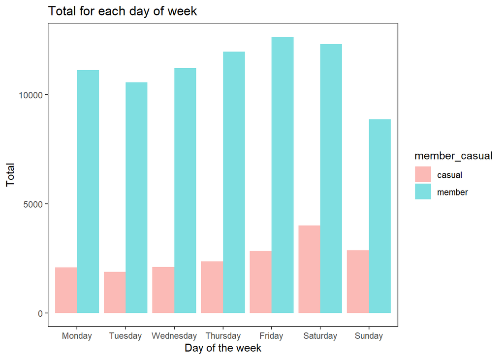

```r
jan_df %>%
  ggplot(aes(x = day_of_week1, fill = member_casual)) +
  geom_bar(position = "dodge", alpha = 0.5) +
  theme_bw() +
  theme(panel.grid.major = element_blank(),
        panel.grid.minor = element_blank()) +
  labs(title = "Total for each day of week",
       x = "Day of the week", y = "Total")
```

#### TOTAL BIKE TYPE USAGE FOR EACH DAY OF WEEK

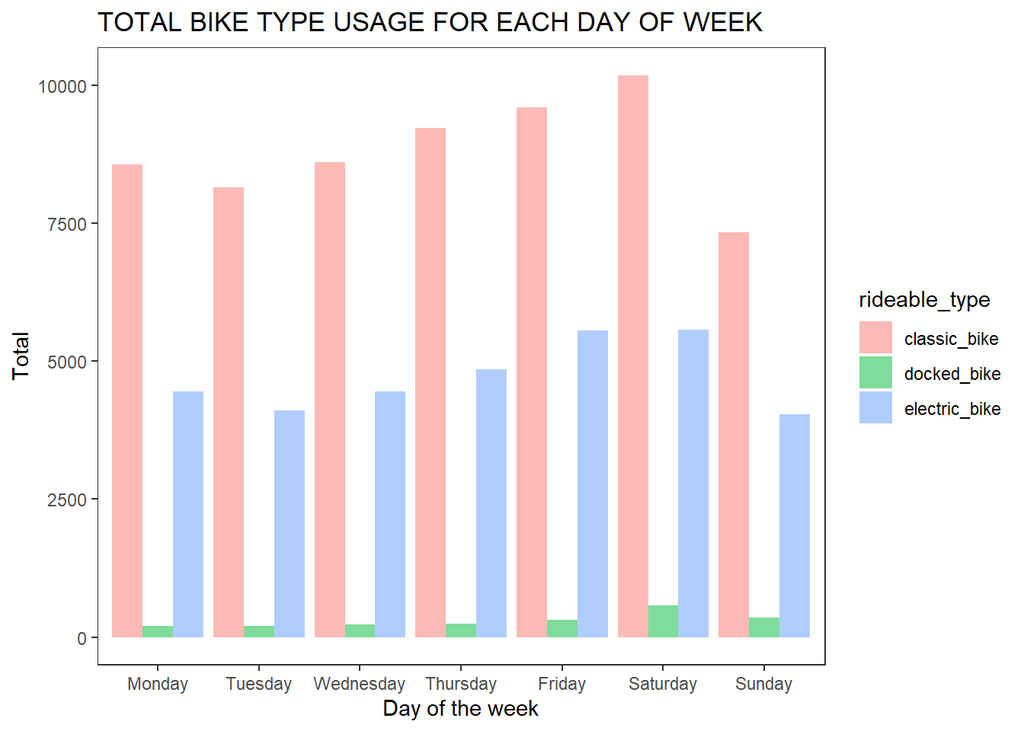

```r
jan_df %>%
  ggplot(aes(x = day_of_week1, fill = rideable_type)) +
  geom_bar(position = "dodge", alpha = 0.5) +
  theme_bw() +
  theme(panel.grid.major = element_blank(),
        panel.grid.minor = element_blank()) +
  labs(title = "TOTAL BIKE TYPE USAGE FOR EACH DAY OF WEEK",
       x = "Day of the week", y = "Total")
```

#### TOTAL USAGE FOR EACH BIKE TYPE

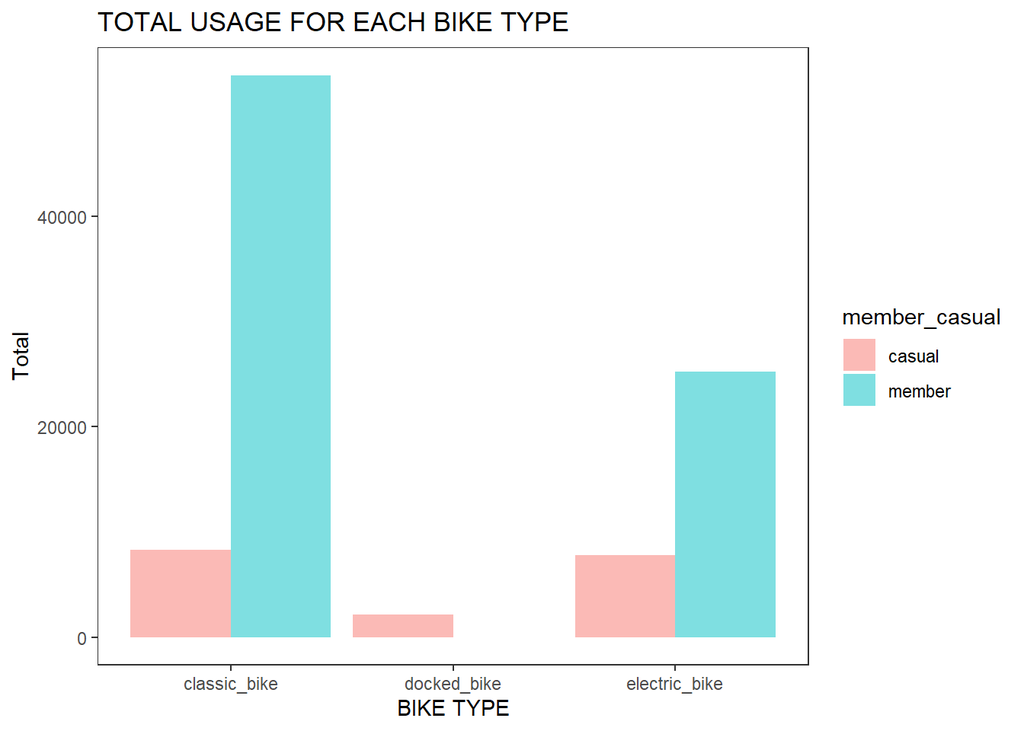

```r
jan_df %>%
  ggplot(aes(x = rideable_type, fill = member_casual)) +
  geom_bar(position = "dodge", alpha = 0.5) +
  theme_bw() +
  theme(panel.grid.major = element_blank(),
        panel.grid.minor = element_blank()) +
  labs(title = "TOTAL USAGE FOR EACH BIKE TYPE",
       x = "BIKE TYPE", y = "Total")
```

Members have the most patronage and we have low patronage for casuals

#### AVERAGE RIDE DURATION FOR CUSTOMER TYPES

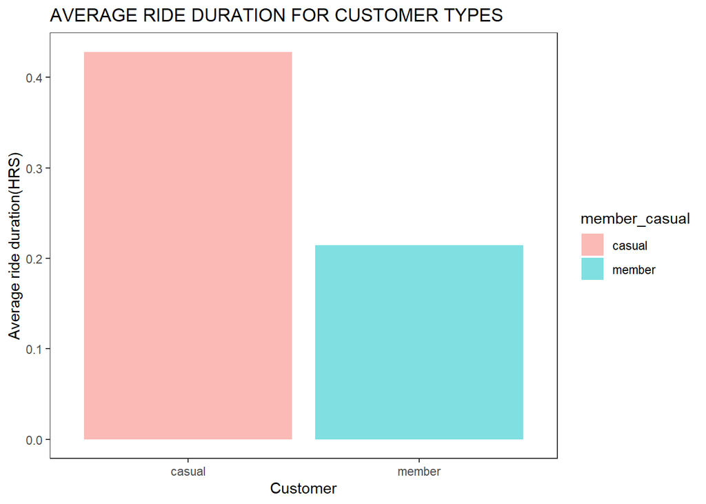

```r
ggplot(data = jan_df, aes(x = member_casual, ride_duration_hrs, fill = member_casual)) +
  geom_bar(position = "dodge", stat = "summary", fun = "mean",
           alpha = 0.5) +
  theme_bw() +
  theme(panel.grid.major = element_blank(),
        panel.grid.minor = element_blank()) +
  labs(title = "AVERAGE RIDE DURATION FOR CUSTOMER TYPES",
       x = "Customer", y = "Average ride duration(HRS)")
```

Higher ride average for casuals compared to members which shows casuals rode for longer

#### AVERAGE RIDE DURATION FOR DIFFERENT WEEKDAYS BASED ON CUSTOMER TYPES

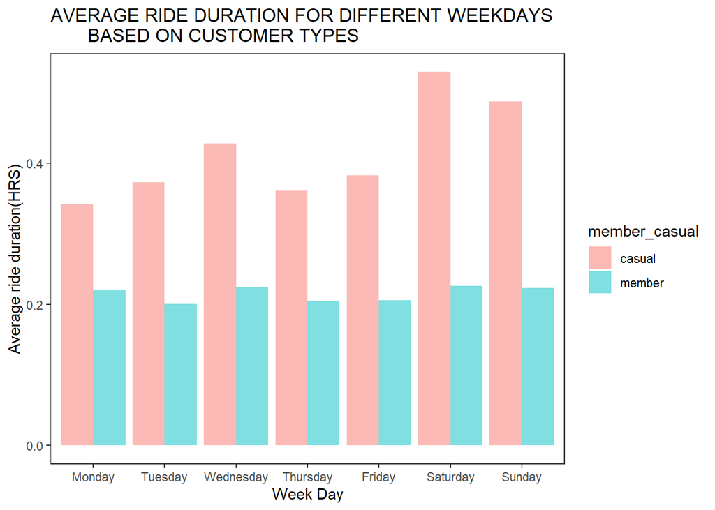

```r
ggplot(data = jan_df, aes(x = day_of_week1, ride_duration_hrs, fill = member_casual)) +
  geom_bar(position = "dodge", stat = "summary", fun = "mean",
           alpha = 0.5) +
  theme_bw() +
  theme(panel.grid.major = element_blank(),
        panel.grid.minor = element_blank()) +
  labs(title = "AVERAGE RIDE DURATION FOR DIFFERENT WEEKDAYS
       BASED ON CUSTOMER TYPES",
       x = "Week Day", y = "Average ride duration(HRS)")
```

Casuals maintain higher averages across all days of the week in January

#### CUSTOMER AVERAGE RIDE DURATION FOR DIFFERENT BIKE TYPES

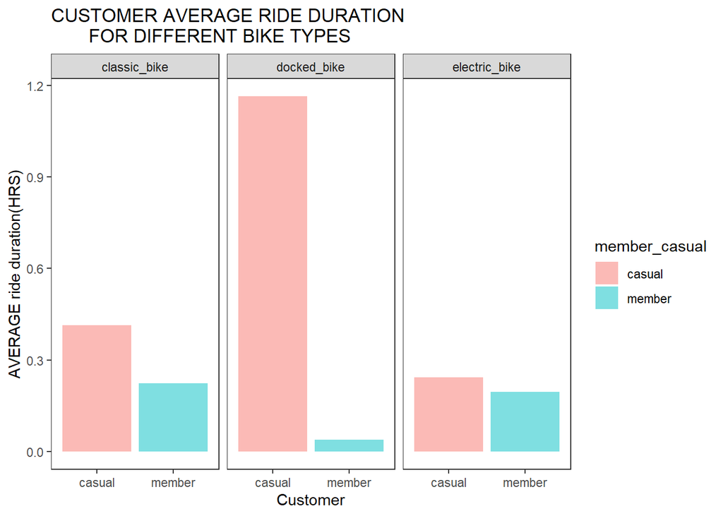

```r
ggplot(data = jan_df, aes(x = member_casual, ride_duration_hrs, fill = member_casual)) +
  geom_bar(position = "dodge", stat = "summary", fun = "mean",
           alpha = 0.5) +
  facet_wrap(~rideable_type) +
  theme_bw() +
  theme(panel.grid.major = element_blank(),
        panel.grid.minor = element_blank()) +
  labs(title = "CUSTOMER AVERAGE RIDE DURATION
       FOR DIFFERENT BIKE TYPES",
       x = "Customer", y = "AVERAGE ride duration(HRS)")
```

Docked bikes by were rode for longer distances by casuals and classics for casuals

#### Max RIDE DURATION FOR CUSTOMER TYPES

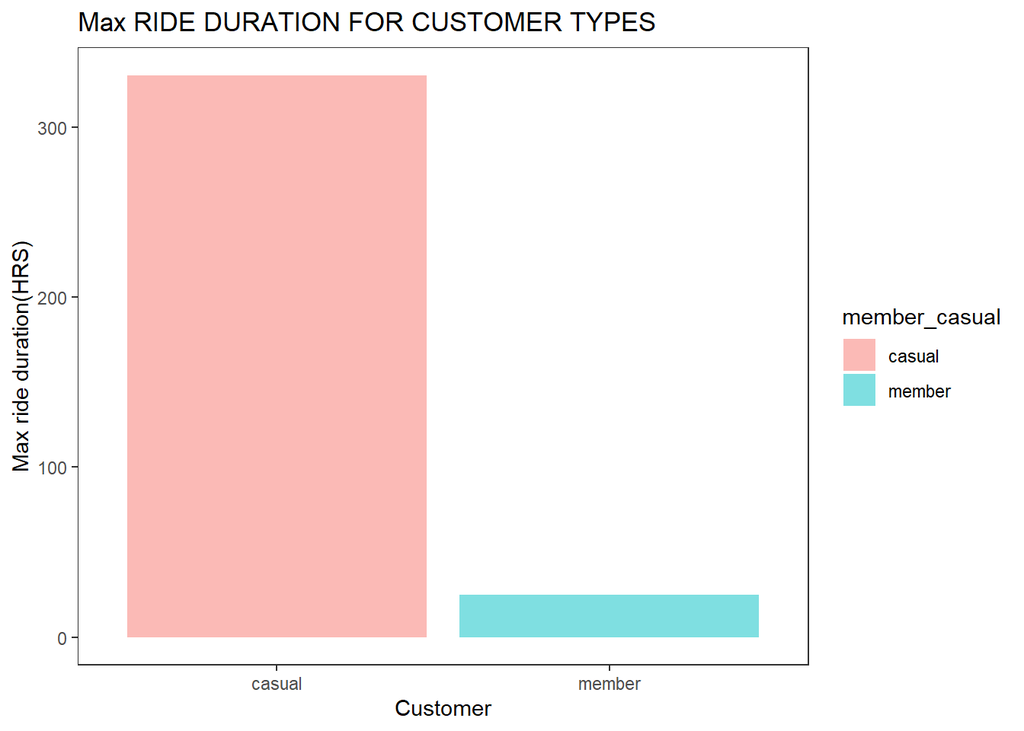

```r
ggplot(data = jan_df, aes(x = member_casual, ride_duration_hrs, fill = member_casual)) +
  geom_bar(position = "dodge", stat = "summary", fun = "max",
           alpha = 0.5) +
  theme_bw() +
  theme(panel.grid.major = element_blank(),
        panel.grid.minor = element_blank()) +
  labs(title = "Max RIDE DURATION FOR CUSTOMER TYPES",
       x = "Customer", y = "Max ride duration(HRS)")
```

Max ride duration for casuals because of higher docked bike averages

#### CUSTOMER Max RIDE DURATION FOR DIFFERENT BIKE TYPES

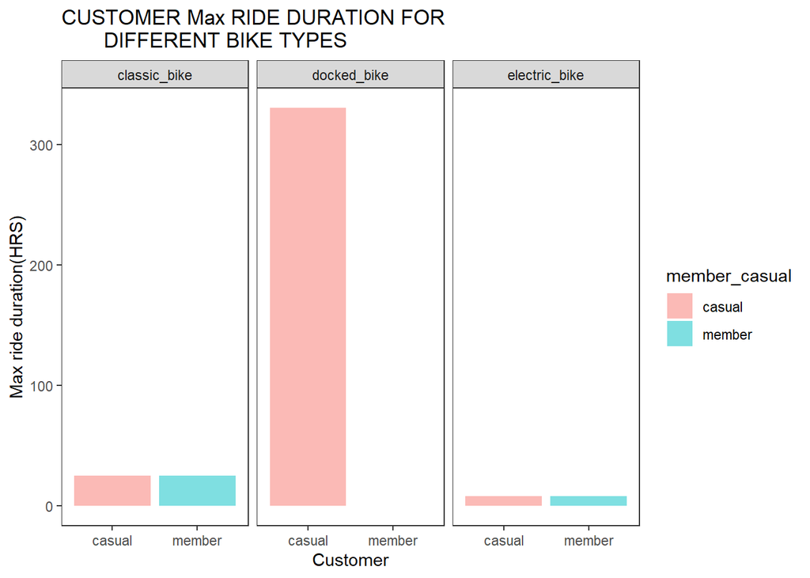

```r
ggplot(data = jan_df, aes(x = member_casual, ride_duration_hrs, fill = member_casual)) +
  geom_bar(position = "dodge", stat = "summary", fun = "max",
           alpha = 0.5) +
  facet_wrap(~rideable_type) +
  theme_bw() +
  theme(panel.grid.major = element_blank(),
        panel.grid.minor = element_blank()) +
  labs(title = "CUSTOMER Max RIDE DURATION FOR
       DIFFERENT BIKE TYPES",
       x = "Customer", y = "Max ride duration(HRS)")
```

Docked bikes shows highest ride duration for January

### FEBRARY ANALYSIS

```r
feb_df <- read_csv("C:/Users/user/Desktop/Case Study/CASESTUDY CYCLING DATA/Cleaned Data/202102-divvy-tripdata_cleaned.csv")
head(feb_df)
```

```
## # A tibble: 6 x 18
##   ride_id        ridea~1 start~2 ended~3 ride_~4 ride_~5 day_o~6 start~7 start~8
##   <chr>          <chr>   <chr>   <chr>   <chr>   <time>  <chr>   <chr>   <chr>
## 1 89E7AA6C29227~ classi~ 2/12/2~ 2/12/2~ 2/12/2~ 06'47"  Friday  Glenwo~ 525
## 2 0FEFDE2603568~ classi~ 2/14/2~ 2/14/2~ 2/14/2~ 19'31"  Sunday  Glenwo~ 525
## 3 E6159D746B2DB~ electr~ 2/9/20~ 2/9/20~ 2/9/20~ 08'52"  Tuesday Clark ~ KA1503~
## 4 B32D3199F1C2E~ classi~ 2/2/20~ 2/2/20~ 2/2/20~ 04'25"  Tuesday Wood S~ 637
## 5 83E463F23575F~ electr~ 2/23/2~ 2/23/2~ 2/23/2~ 15'14"  Tuesday State ~ 13216
## 6 BDAA7E3494E8D~ electr~ 2/24/2~ 2/24/2~ 2/24/2~ 05'32"  Wednes~ Fairba~ 18003
## # ... with 9 more variables: end_station_name <chr>, end_station_id <chr>,
## #   start_lat <dbl>, start_lng <dbl>, end_lat <dbl>, end_lng <dbl>,
## #   member_casual <chr>, week_number <dbl>, ride_duration_hrs <dbl>, and
## #   abbreviated variable names 1: rideable_type, 2: started_at, 3: ended_at,
## #   4: ride_date, 5: ride_duration, 6: day_of_week, 7: start_station_name,
## #   8: start_station_id
## # i Use `colnames()` to see all variable names
```

#### ORDERING THE DAYS OF THE WEEK

```r
feb_df$day_of_week2 <- factor(feb_df$day_of_week, levels = c("Monday", "Tuesday", "Wednesday", "Thursday", "Friday", "Saturday", "Sunday"))
```

#### TOTAL NUMBER OF USERS FOR EACH WEEKDAY

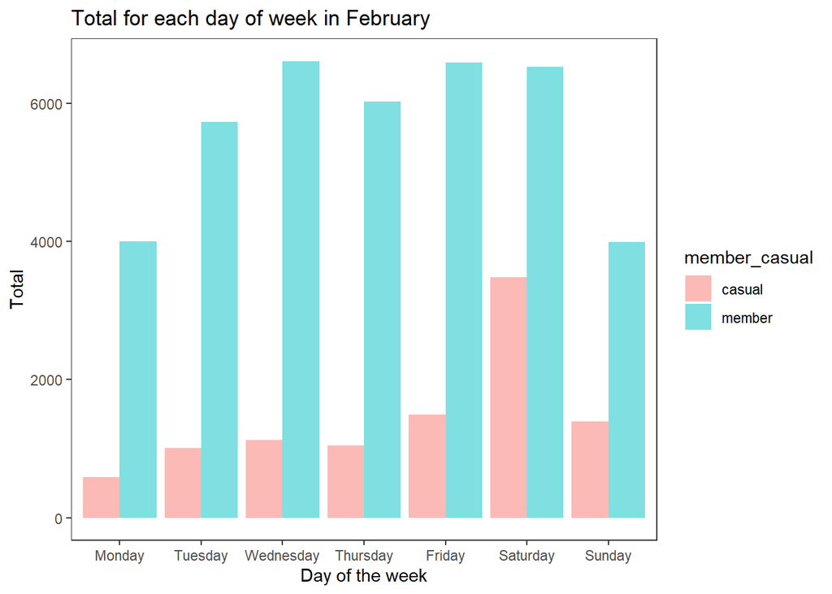

```r
feb_df %>%
  ggplot(aes(x = day_of_week2, fill = member_casual)) +
  geom_bar(position = "dodge", alpha = 0.5) +
  theme_bw() +
  theme(panel.grid.major = element_blank(),
        panel.grid.minor = element_blank()) +
  labs(title = "Total for each day of week in February",
       x = "Day of the week", y = "Total")
```

Members show highest patronage on all days

#### TOTAL BIKE TYPE USAGE FOR EACH DAY OF WEEK

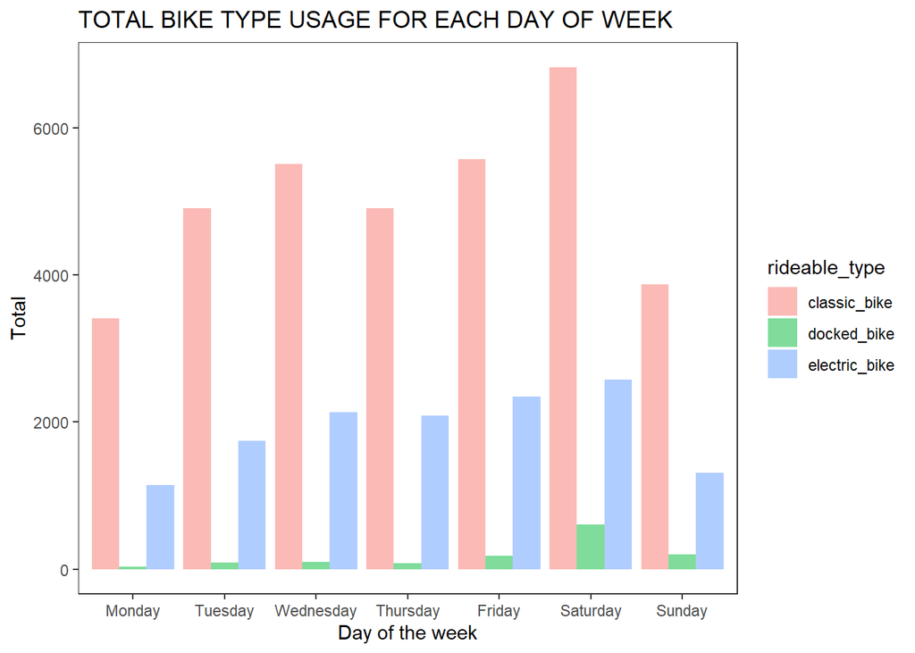

```r
feb_df %>%
  ggplot(aes(x = day_of_week2, fill = rideable_type)) +
  geom_bar(position = "dodge", alpha = 0.5) +
  theme_bw() +
  theme(panel.grid.major = element_blank(),
        panel.grid.minor = element_blank()) +
  labs(title = "TOTAL BIKE TYPE USAGE FOR EACH DAY OF WEEK",
       x = "Day of the week", y = "Total")
```

Classic bikes remain the most used bike with the highest use on Saturday

#### TOTAL USAGE FOR EACH BIKE TYPE

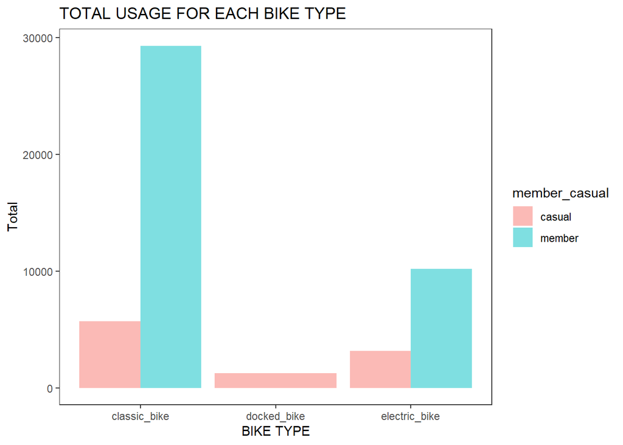

```r
feb_df %>%
  ggplot(aes(x = rideable_type, fill = member_casual)) +
  geom_bar(position = "dodge", alpha = 0.5) +
  theme_bw() +
  theme(panel.grid.major = element_blank(),
        panel.grid.minor = element_blank()) +
  labs(title = "TOTAL USAGE FOR EACH BIKE TYPE",
       x = "BIKE TYPE", y = "Total")
```

Members had the highest patronage with classic bikes

#### AVERAGE RIDE DURATION FOR CUSTOMER TYPES

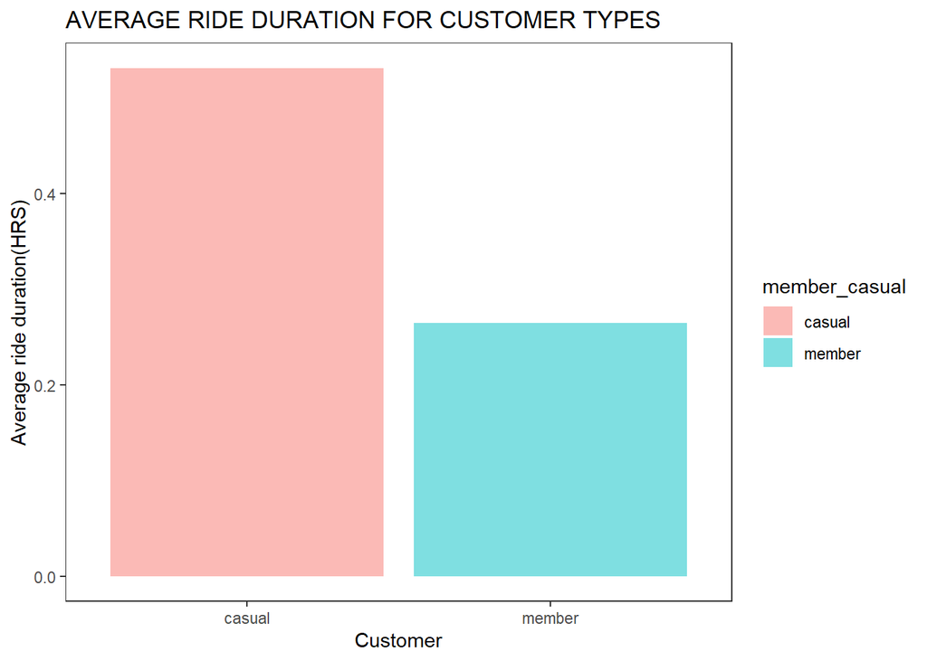

```r
ggplot(data = feb_df, aes(x = member_casual, ride_duration_hrs, fill = member_casual)) +
  geom_bar(position = "dodge", stat = "summary",
           fun = "mean",alpha = 0.5) +
  theme_bw() +
  theme(panel.grid.major = element_blank(),
        panel.grid.minor = element_blank()) +
  labs(title = "AVERAGE RIDE DURATION FOR CUSTOMER TYPES",
       x = "Customer", y = "Average ride duration(HRS)")
```

Casual users had the highest average in February

#### AVERAGE RIDE DURATION FOR DIFFERENT WEEKDAYS BASED ON CUSTOMER TYPES

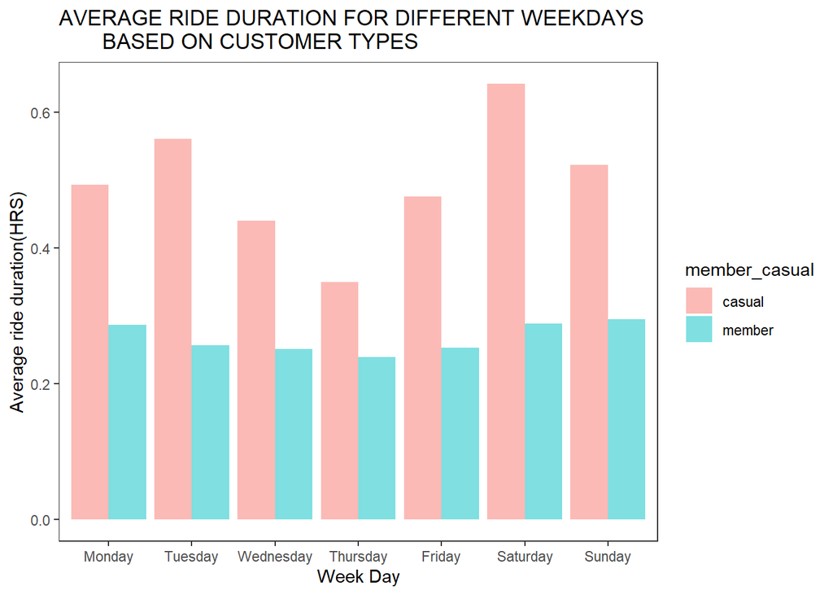

```r
ggplot(data = feb_df, aes(x = day_of_week2, ride_duration_hrs, fill = member_casual)) +
  geom_bar(position = "dodge", stat = "summary",
           fun = "mean",alpha = 0.5) +
  theme_bw() +
  theme(panel.grid.major = element_blank(),
        panel.grid.minor = element_blank()) +
  labs(title = "AVERAGE RIDE DURATION FOR DIFFERENT WEEKDAYS
       BASED ON CUSTOMER TYPES",
       x = "Week Day", y = "Average ride duration(HRS)")
```

Higher averages for all casual users across all days

#### CUSTOMER AVERAGE RIDE DURATION FOR DIFFERENT BIKE TYPES

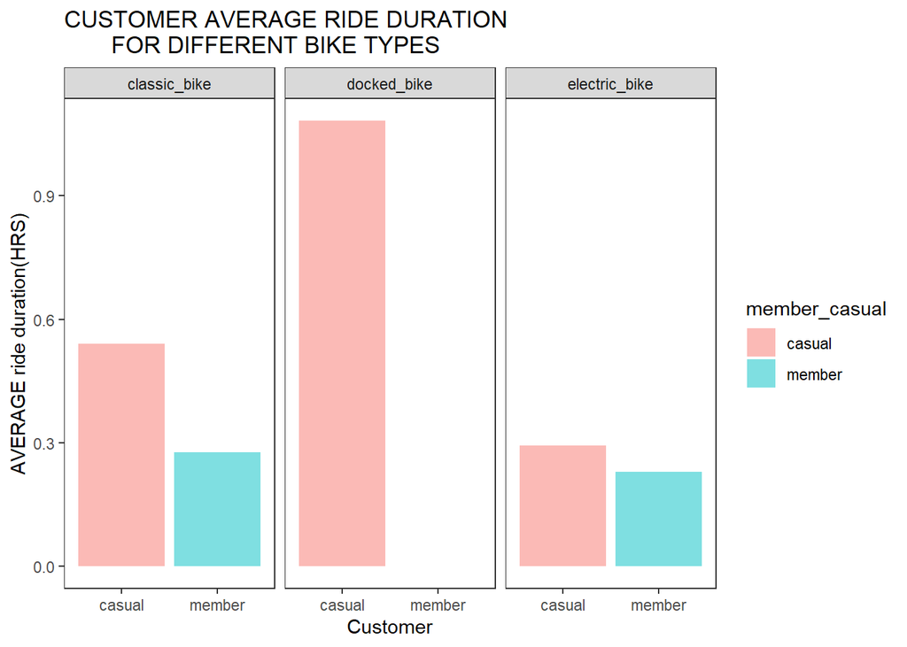

```r
ggplot(data = feb_df, aes(x = member_casual, ride_duration_hrs, fill = member_casual)) +
  geom_bar(position = "dodge", stat = "summary",
           fun = "mean",alpha = 0.5) +
  facet_wrap(~rideable_type) +
  theme_bw() +
  theme(panel.grid.major = element_blank(),
        panel.grid.minor = element_blank()) +
  labs(title = "CUSTOMER AVERAGE RIDE DURATION
       FOR DIFFERENT BIKE TYPES",
       x = "Customer", y = "AVERAGE ride duration(HRS)")
```

Docked bikes have the highest averages across the bike types

#### Max RIDE DURATION FOR CUSTOMER TYPES

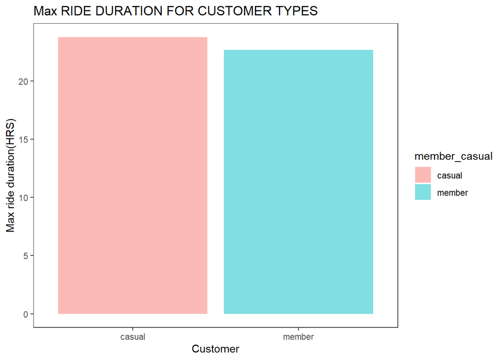

```r
ggplot(data = feb_df, aes(x = member_casual, ride_duration_hrs, fill = member_casual)) +
  geom_bar(position = "dodge", stat = "summary",
           fun = "max",alpha = 0.5) +
  theme_bw() +
  theme(panel.grid.major = element_blank(),
        panel.grid.minor = element_blank()) +
  labs(title = "Max RIDE DURATION FOR CUSTOMER TYPES",
       x = "Customer", y = "Max ride duration(HRS)")
```

Close Maximum ride duration for both User types

#### CUSTOMER Max RIDE DURATION FOR DIFFERENT BIKE TYPES

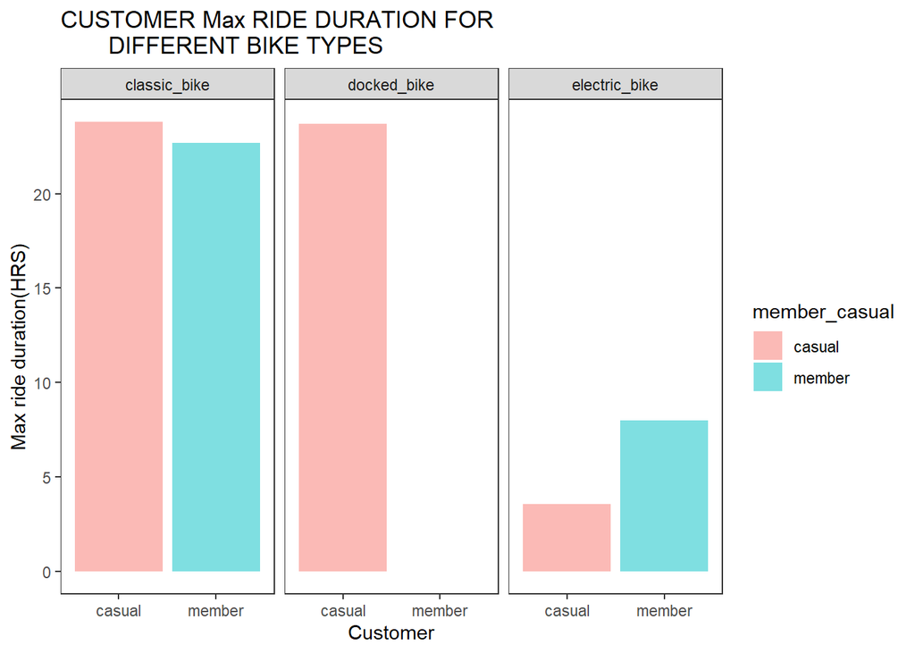

```r
ggplot(data = feb_df, aes(x = member_casual, ride_duration_hrs, fill = member_casual)) +
  geom_bar(position = "dodge", stat = "summary",
           fun = "max",alpha = 0.5) +
  facet_wrap(~rideable_type) +
  theme_bw() +
  theme(panel.grid.major = element_blank(),
        panel.grid.minor = element_blank()) +
  labs(title = "CUSTOMER Max RIDE DURATION FOR
       DIFFERENT BIKE TYPES",
       x = "Customer", y = "Max ride duration(HRS)")
```

### MARCH ANALYSIS

```r
mar_df <- read_csv("C:/Users/user/Desktop/Case Study/CASESTUDY CYCLING DATA/Cleaned Data/202103-divvy-tripdata_cleaned.csv")
head(mar_df)
```

```
## # A tibble: 6 x 18
##   ride_id        ridea~1 start~2 ended~3 ride_~4 ride_~5 day_o~6 start~7 start~8
##   <chr>          <chr>   <chr>   <chr>   <chr>   <time>  <chr>   <chr>   <chr>
## 1 CFA86D4455AA1~ classi~ 3/16/2~ 3/16/2~ 3/16/2~ 04'04"  Tuesday Humbol~ 15651
## 2 30D9DC61227D1~ classi~ 3/28/2~ 3/28/2~ 3/28/2~ 10'27"  Sunday  Humbol~ 15651
## 3 846D87A15682A~ classi~ 3/11/2~ 3/11/2~ 3/11/2~ 16'24"  Thursd~ Shield~ 15443
## 4 994D05AA75A16~ classi~ 3/11/2~ 3/11/2~ 3/11/2~ 28'59"  Thursd~ Winthr~ TA1308~
## 5 DF7464FBE92D8~ classi~ 3/21/2~ 3/21/2~ 3/21/2~ 17'56"  Sunday  Glenwo~ 525
## 6 CEBA8516FD17F~ classi~ 3/20/2~ 3/20/2~ 3/20/2~ 20'52"  Saturd~ Glenwo~ 525
## # ... with 9 more variables: end_station_name <chr>, end_station_id <chr>,
## #   start_lat <dbl>, start_lng <dbl>, end_lat <dbl>, end_lng <dbl>,
## #   member_casual <chr>, week_number <dbl>, ride_duration_hrs <dbl>, and
## #   abbreviated variable names 1: rideable_type, 2: started_at, 3: ended_at,
## #   4: ride_date, 5: ride_duration, 6: day_of_week, 7: start_station_name,
## #   8: start_station_id
## # i Use `colnames()` to see all variable names
```

#### ORDERING THE DAYS OF THE WEEK

```r
mar_df$day_of_week3 <- factor(mar_df$day_of_week, levels = c("Monday", "Tuesday", "Wednesday", "Thursday", "Friday", "Saturday", "Sunday"))
```

#### TOTAL FOR EACH DAY OF WEEK

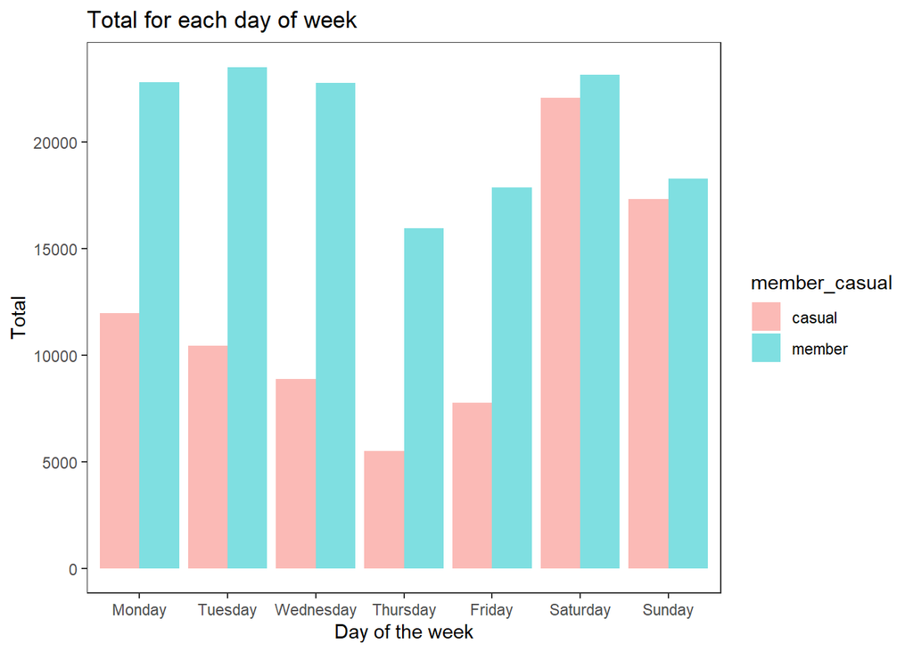

```r
mar_df %>%
  ggplot(aes(x = day_of_week3, fill = member_casual)) +
  geom_bar(position = "dodge", alpha = 0.5) +
  theme_bw() +
  theme(panel.grid.major = element_blank(),
        panel.grid.minor = element_blank()) +
  labs(title = "Total for each day of week",
       x = "Day of the week", y = "Total")
```

Higher patronage for members in the weekdays but close figures on weekends

#### TOTAL BIKE TYPE USAGE FOR EACH DAY OF WEEK

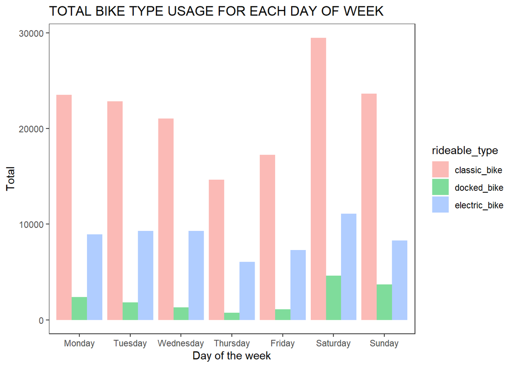

```r
mar_df %>%
  ggplot(aes(x = day_of_week3, fill = rideable_type)) +
  geom_bar(position = "dodge", alpha = 0.5) +
  theme_bw() +
  theme(panel.grid.major = element_blank(),
        panel.grid.minor = element_blank()) +
  labs(title = "TOTAL BIKE TYPE USAGE FOR EACH DAY OF WEEK",
       x = "Day of the week", y = "Total")
```

Classic bikes has the highest patronage across all weekdays

#### TOTAL USAGE FOR EACH BIKE TYPE

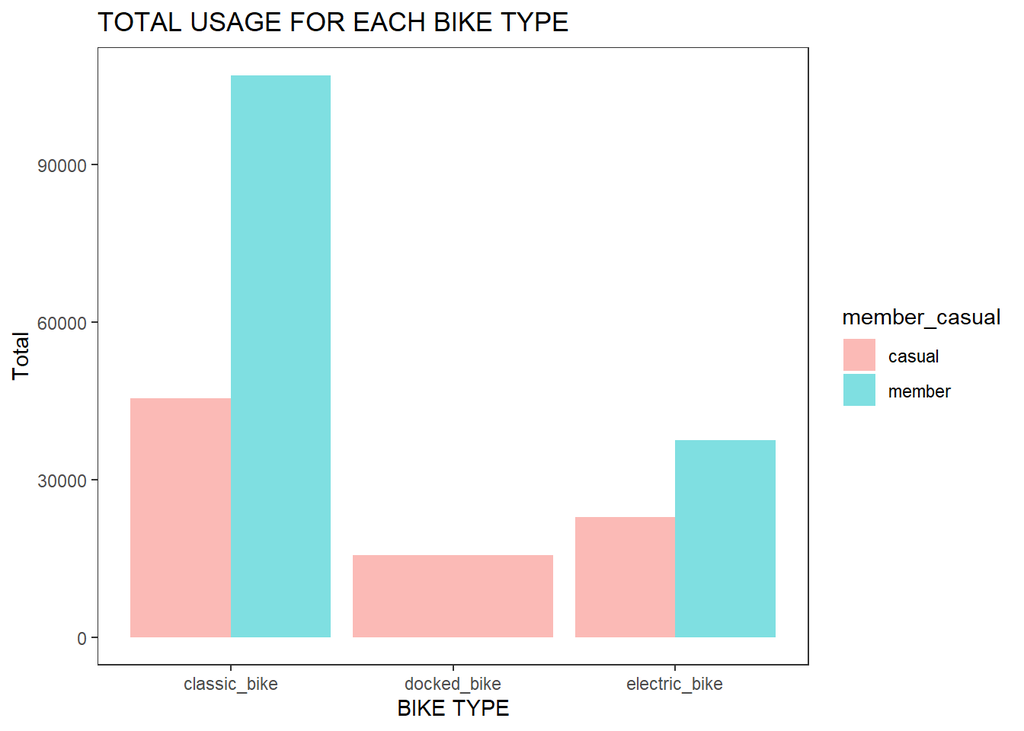

```r
mar_df %>%
  ggplot(aes(x = rideable_type, fill = member_casual)) +
  geom_bar(position = "dodge", alpha = 0.5) +
  theme_bw() +
  theme(panel.grid.major = element_blank(),
        panel.grid.minor = element_blank()) +
  labs(title = "TOTAL USAGE FOR EACH BIKE TYPE",
       x = "BIKE TYPE", y = "Total")
```

As shown earlier classic bikes had the highest patronage by members patronage from Casuals generally low

#### AVERAGE RIDE DURATION FOR CUSTOMER TYPES

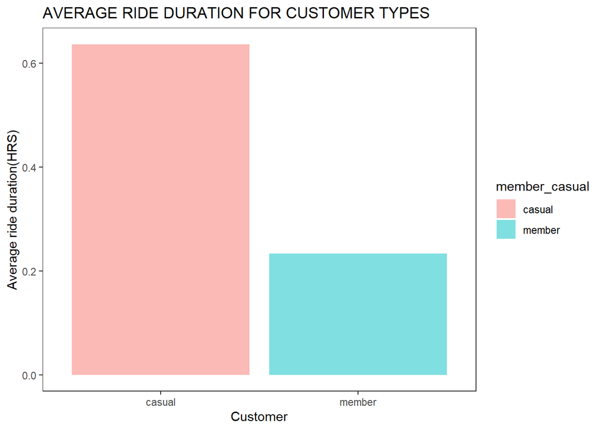

```r
ggplot(data = mar_df, aes(x = member_casual, ride_duration_hrs, fill = member_casual)) +
  geom_bar(position = "dodge", stat = "summary",
           fun = "mean",alpha = 0.5) +
  theme_bw() +
  theme(panel.grid.major = element_blank(),
        panel.grid.minor = element_blank()) +
  labs(title = "AVERAGE RIDE DURATION FOR CUSTOMER TYPES",
       x = "Customer", y = "Average ride duration(HRS)")
```

Higher Average for casual users

#### AVERAGE RIDE DURATION FOR DIFFERENT WEEKDAYS BASED ON CUSTOMER TYPES

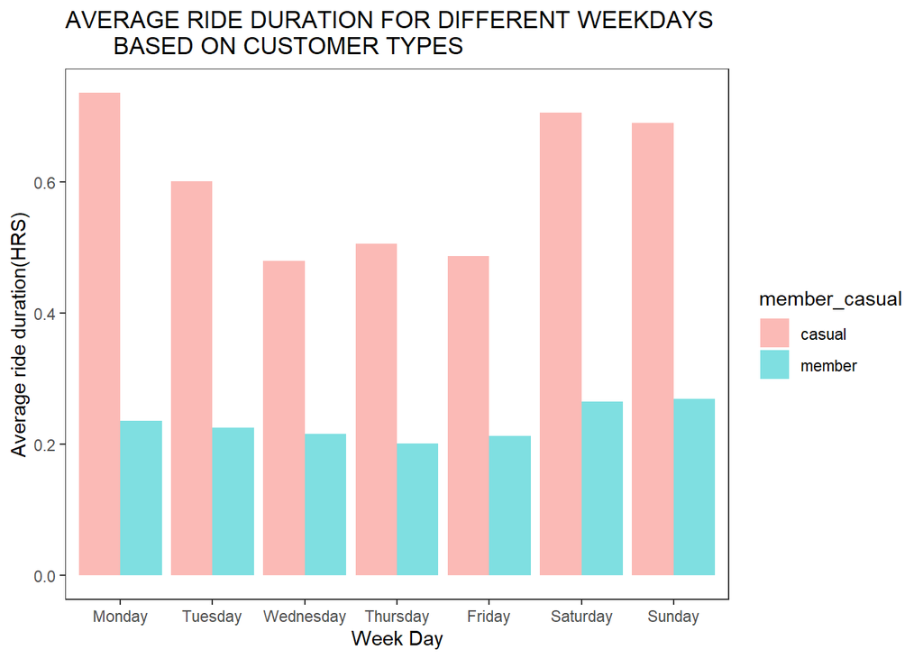

```r
ggplot(data = mar_df, aes(x = day_of_week3, ride_duration_hrs, fill = member_casual)) +
  geom_bar(position = "dodge", stat = "summary",
           fun = "mean",alpha = 0.5) +
  theme_bw() +
  theme(panel.grid.major = element_blank(),
        panel.grid.minor = element_blank()) +
  labs(title = "AVERAGE RIDE DURATION FOR DIFFERENT WEEKDAYS
       BASED ON CUSTOMER TYPES",
       x = "Week Day", y = "Average ride duration(HRS)")
```

#### CUSTOMER AVERAGE RIDE DURATION FOR DIFFERENT BIKE TYPES

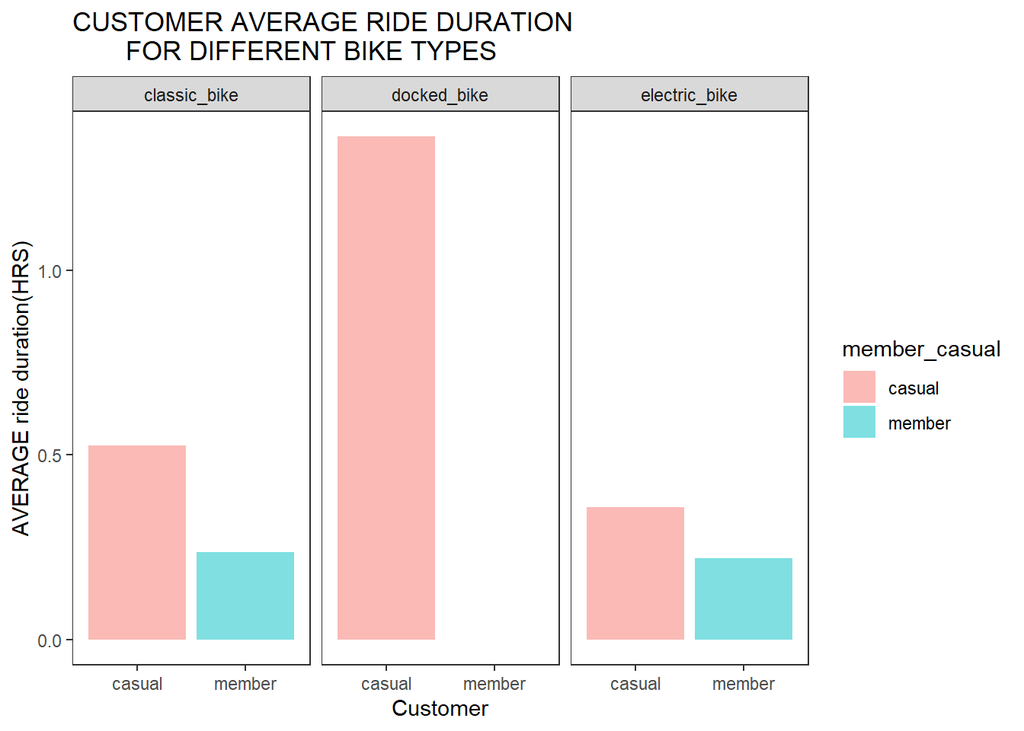

```r
ggplot(data = mar_df, aes(x = member_casual, ride_duration_hrs, fill = member_casual)) +
  geom_bar(position = "dodge", stat = "summary",
           fun = "mean",alpha = 0.5) +
  facet_wrap(~rideable_type) +
  theme_bw() +
  theme(panel.grid.major = element_blank(),
        panel.grid.minor = element_blank()) +
  labs(title = "CUSTOMER AVERAGE RIDE DURATION
       FOR DIFFERENT BIKE TYPES",
       x = "Customer", y = "AVERAGE ride duration(HRS)")
```

#### Max RIDE DURATION FOR CUSTOMER TYPES

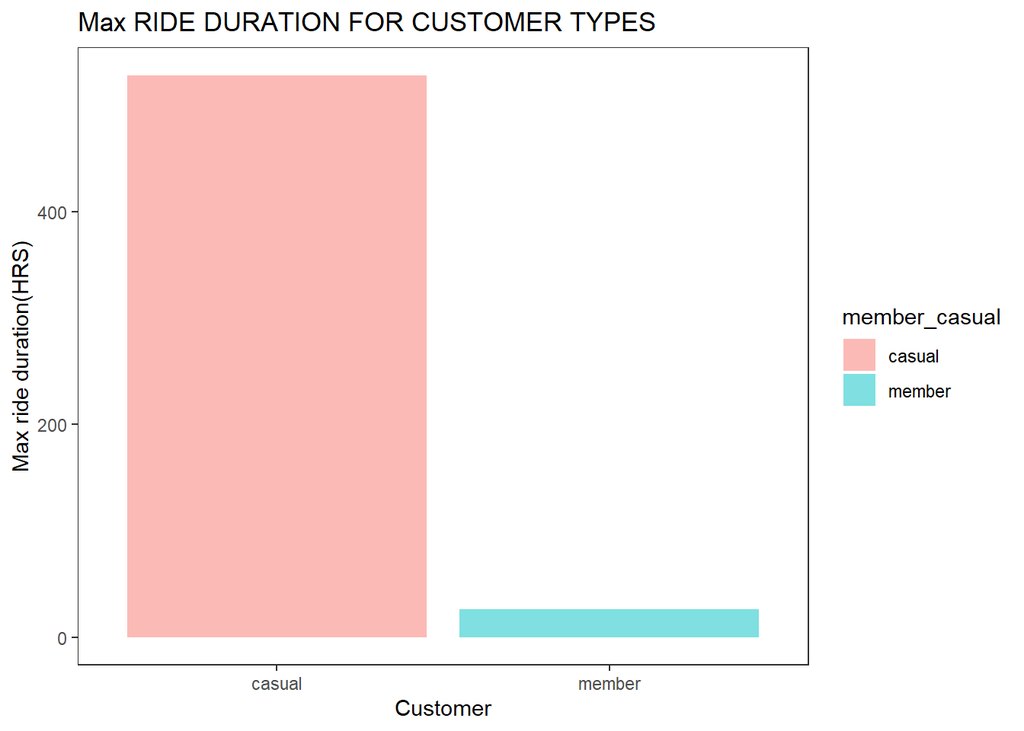

```r
ggplot(data = mar_df, aes(x = member_casual, ride_duration_hrs, fill = member_casual)) +
  geom_bar(position = "dodge", stat = "summary",
           fun = "max",alpha = 0.5) +
  theme_bw() +
  theme(panel.grid.major = element_blank(),
        panel.grid.minor = element_blank()) +
  labs(title = "Max RIDE DURATION FOR CUSTOMER TYPES",
       x = "Customer", y = "Max ride duration(HRS)")
```

Max Ride duration recorded for casuals

#### CUSTOMER Max RIDE DURATION FOR DIFFERENT BIKE TYPES

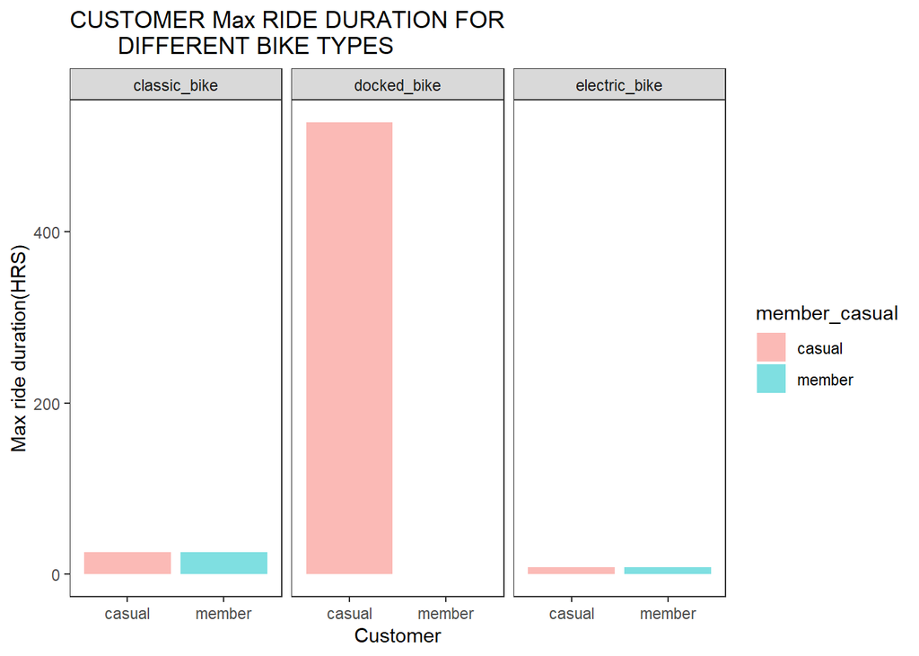

```r
ggplot(data = mar_df, aes(x = member_casual, ride_duration_hrs, fill = member_casual)) +
  geom_bar(position = "dodge", stat = "summary",
           fun = "max",alpha = 0.5) +
  facet_wrap(~rideable_type) +
  theme_bw() +
  theme(panel.grid.major = element_blank(),
        panel.grid.minor = element_blank()) +
  labs(title = "CUSTOMER Max RIDE DURATION FOR
       DIFFERENT BIKE TYPES",
       x = "Customer", y = "Max ride duration(HRS)")
```

Highest Maximum duration attributed to Docked bike types by Casuals

### APRIL ANALYSIS

```r
apr_df <- read_csv("C:/Users/user/Desktop/Case Study/CASESTUDY CYCLING DATA/Cleaned Data/202104-divvy-tripdata_cleaned.csv")
head(apr_df)
```

```
## # A tibble: 6 x 18
##   ride_id       ridea~1 start~2 ended~3 ride_~4 ride_d~5 day_o~6 start~7 start~8
##   <chr>         <chr>   <chr>   <chr>   <chr>   <time>   <chr>   <chr>   <chr>
## 1 6C992BD37A98~ classi~ 4/12/2~ 4/12/2~ 4/12/2~ 00:31:19 Monday  State ~ TA1307~
## 2 1E0145613A20~ docked~ 4/27/2~ 4/27/2~ 4/27/2~ 01:04:18 Tuesday Dorche~ KA1503~
## 3 E498E15508A8~ docked~ 4/3/20~ 4/7/20~ 4/3/20~ 94:57:39 Saturd~ Loomis~ 20121
## 4 1887262AD101~ classi~ 4/17/2~ 4/17/2~ 4/17/2~ 00:25:06 Saturd~ Honore~ TA1305~
## 5 C123548CAB2A~ docked~ 4/3/20~ 4/3/20~ 4/3/20~ 01:31:17 Saturd~ Loomis~ 20121
## 6 097E76F3651B~ classi~ 4/25/2~ 4/25/2~ 4/25/2~ 00:00:41 Sunday  Clinto~ 15542
## # ... with 9 more variables: end_station_name <chr>, end_station_id <chr>,
## #   start_lat <dbl>, start_lng <dbl>, end_lat <dbl>, end_lng <dbl>,
## #   member_casual <chr>, week_number <dbl>, ride_duration_hrs <dbl>, and
## #   abbreviated variable names 1: rideable_type, 2: started_at, 3: ended_at,
## #   4: ride_date, 5: ride_duration, 6: day_of_week, 7: start_station_name,
## #   8: start_station_id
## # i Use `colnames()` to see all variable names
```

#### ORDERING THE DAYS OF THE WEEK

```r
apr_df$day_of_week4 <- factor(apr_df$day_of_week, levels = c("Monday", "Tuesday", "Wednesday", "Thursday", "Friday", "Saturday", "Sunday"))
```

#### Total for each day of week

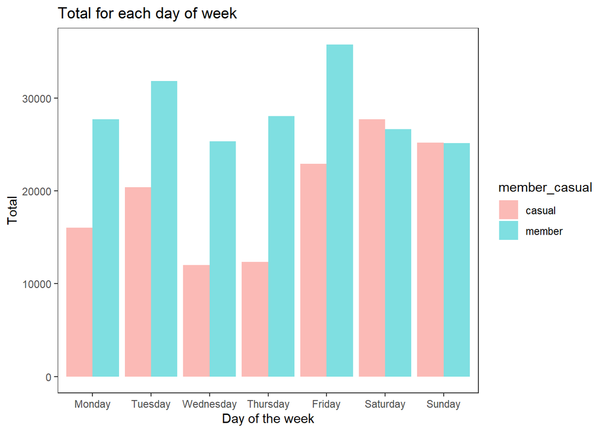

```r
apr_df %>%
  ggplot(aes(x = day_of_week4, fill = member_casual)) +
  geom_bar(position = "dodge", alpha = 0.5) +
  theme_bw() +
  theme(panel.grid.major = element_blank(),
        panel.grid.minor = element_blank()) +
  labs(title = "Total for each day of week",
       x = "Day of the week", y = "Total")
```

Numbers start rising with member patronage higher on weekdays and close on weekends

#### TOTAL BIKE TYPE USAGE FOR EACH DAY OF WEEK

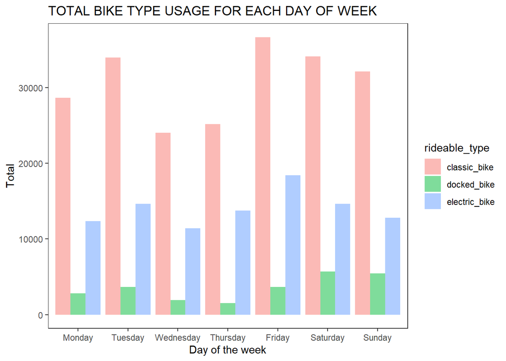

```r
apr_df %>%
  ggplot(aes(x = day_of_week4, fill = rideable_type)) +
  geom_bar(position = "dodge", alpha = 0.5) +
  theme_bw() +
  theme(panel.grid.major = element_blank(),
        panel.grid.minor = element_blank()) +
  labs(title = "TOTAL BIKE TYPE USAGE FOR EACH DAY OF WEEK",
       x = "Day of the week", y = "Total")
```

Classic bikes are still the most patronized and Docked types are the least

#### TOTAL USAGE FOR EACH BIKE TYPE

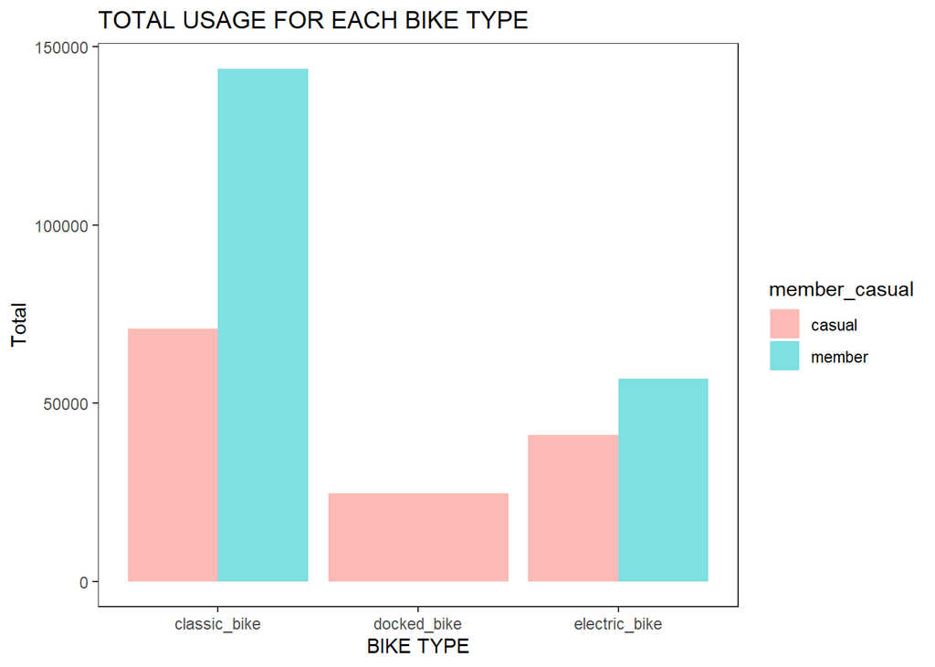

```r
apr_df %>%
  ggplot(aes(x = rideable_type, fill = member_casual)) +
  geom_bar(position = "dodge", alpha = 0.5) +
  theme_bw() +
  theme(panel.grid.major = element_blank(),
        panel.grid.minor = element_blank()) +
  labs(title = "TOTAL USAGE FOR EACH BIKE TYPE",
       x = "BIKE TYPE", y = "Total")
```

Members and casuals patronized classic bikes the most

#### AVERAGE RIDE DURATION FOR CUSTOMER TYPES

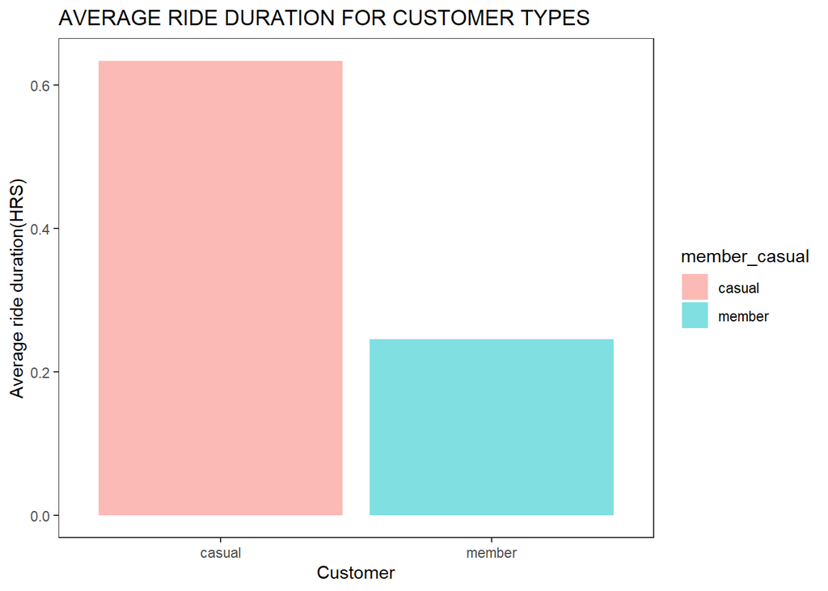

```r
ggplot(data = apr_df, aes(x = member_casual, ride_duration_hrs, fill = member_casual)) +
  geom_bar(position = "dodge", stat = "summary",
           fun = "mean",alpha = 0.5) +
  theme_bw() +
  theme(panel.grid.major = element_blank(),
        panel.grid.minor = element_blank()) +
  labs(title = "AVERAGE RIDE DURATION FOR CUSTOMER TYPES",
       x = "Customer", y = "Average ride duration(HRS)")
```

Casuals continue to maintain higher averages for ride durations

#### AVERAGE RIDE DURATION FOR DIFFERENT WEEKDAYS BASED ON CUSTOMER TYPES

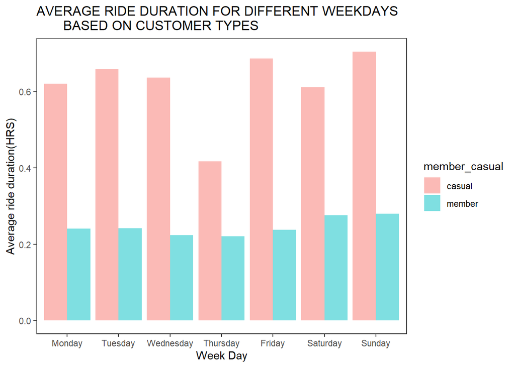

```r
ggplot(data = apr_df, aes(x = day_of_week4, ride_duration_hrs, fill = member_casual)) +
  geom_bar(position = "dodge", stat = "summary",
           fun = "mean",alpha = 0.5) +
  theme_bw() +
  theme(panel.grid.major = element_blank(),
        panel.grid.minor = element_blank()) +
  labs(title = "AVERAGE RIDE DURATION FOR DIFFERENT WEEKDAYS
       BASED ON CUSTOMER TYPES",
       x = "Week Day", y = "Average ride duration(HRS)")
```

#### CUSTOMER AVERAGE RIDE DURATION FOR DIFFERENT BIKE TYPE

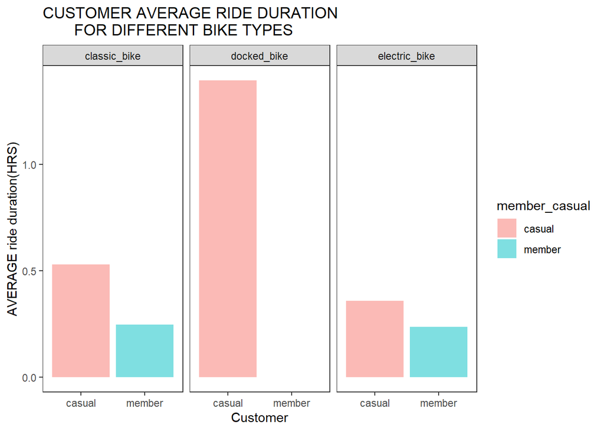

```r
ggplot(data = apr_df, aes(x = member_casual, ride_duration_hrs, fill = member_casual)) +
  geom_bar(position = "dodge", stat = "summary",
           fun = "mean",alpha = 0.5) +
  facet_wrap(~rideable_type) +
  theme_bw() +
  theme(panel.grid.major = element_blank(),
        panel.grid.minor = element_blank()) +
  labs(title = "CUSTOMER AVERAGE RIDE DURATION
       FOR DIFFERENT BIKE TYPES",
       x = "Customer", y = "AVERAGE ride duration(HRS)")
```

Docked bikes have the highest Max duration

#### Max RIDE DURATION FOR CUSTOMER TYPES

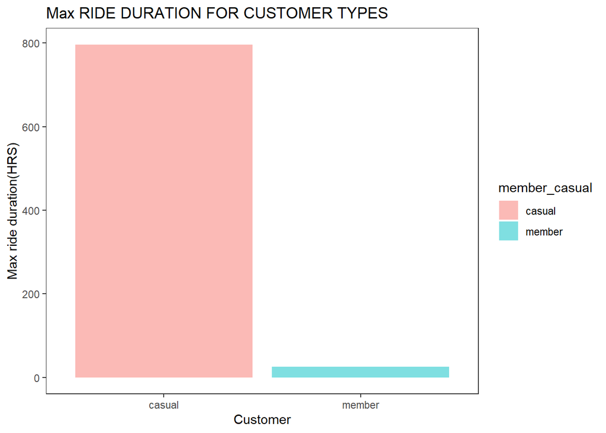

```r
ggplot(data = apr_df, aes(x = member_casual, ride_duration_hrs, fill = member_casual)) +
  geom_bar(position = "dodge", stat = "summary",
           fun = "max",alpha = 0.5) +
  theme_bw() +
  theme(panel.grid.major = element_blank(),
        panel.grid.minor = element_blank()) +
  labs(title = "Max RIDE DURATION FOR CUSTOMER TYPES",
       x = "Customer", y = "Max ride duration(HRS)")
```

#### CUSTOMER Max RIDE DURATION FOR DIFFERENT BIKE TYPES

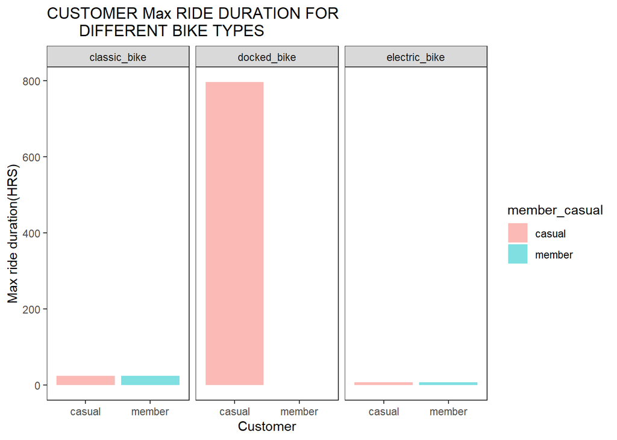

```r
ggplot(data = apr_df, aes(x = member_casual, ride_duration_hrs, fill = member_casual)) +
  geom_bar(position = "dodge", stat = "summary",
           fun = "max",alpha = 0.5) +
  facet_wrap(~rideable_type) +
  theme_bw() +
  theme(panel.grid.major = element_blank(),
        panel.grid.minor = element_blank()) +
  labs(title = "CUSTOMER Max RIDE DURATION FOR
       DIFFERENT BIKE TYPES",
       x = "Customer", y = "Max ride duration(HRS)")
```

Only Casuals users patronize Docked type bikes for long distances

#### MAY ANALYSIS

```r
may_df <- read_csv("C:/Users/user/Desktop/Case Study/CASESTUDY CYCLING DATA/Cleaned Data/202105-divvy-tripdata_cleaned.csv")
head(may_df)
```

```
## # A tibble: 6 x 18
##   ride_id        ridea~1 start~2 ended~3 ride_~4 ride_~5 day_o~6 start~7 start~8
##   <chr>          <chr>   <chr>   <chr>   <chr>   <time>  <chr>   <chr>   <chr>
## 1 C809ED75D6160~ electr~ 5/30/2~ 5/30/2~ 5/30/2~ 12'24"  Sunday  <NA>    <NA>
## 2 DD59FDCE0ACAC~ electr~ 5/30/2~ 5/30/2~ 5/30/2~ 44'55"  Sunday  <NA>    <NA>
## 3 0AB83CB88C43E~ electr~ 5/30/2~ 5/30/2~ 5/30/2~ 01'12"  Sunday  <NA>    <NA>
## 4 7881AC6D39110~ electr~ 5/30/2~ 5/30/2~ 5/30/2~ 15'13"  Sunday  <NA>    <NA>
## 5 853FA701B4582~ electr~ 5/30/2~ 5/30/2~ 5/30/2~ 06'53"  Sunday  <NA>    <NA>
## 6 F5E63DFD96B2A~ electr~ 5/30/2~ 5/30/2~ 5/30/2~ 23'36"  Sunday  <NA>    <NA>
## # ... with 9 more variables: end_station_name <chr>, end_station_id <chr>,
## #   start_lat <dbl>, start_lng <dbl>, end_lat <dbl>, end_lng <dbl>,
## #   member_casual <chr>, week_number <dbl>, ride_duration_hrs <dbl>, and
## #   abbreviated variable names 1: rideable_type, 2: started_at, 3: ended_at,
## #   4: ride_date, 5: ride_duration, 6: day_of_week, 7: start_station_name,
## #   8: start_station_id
## # i Use `colnames()` to see all variable names
```

#### ORDERING THE DAYS OF THE WEEK

```r
may_df$day_of_week5 <- factor(may_df$day_of_week, levels = c("Monday", "Tuesday", "Wednesday", "Thursday", "Friday", "Saturday", "Sunday"))
```

#### Total for each day of week

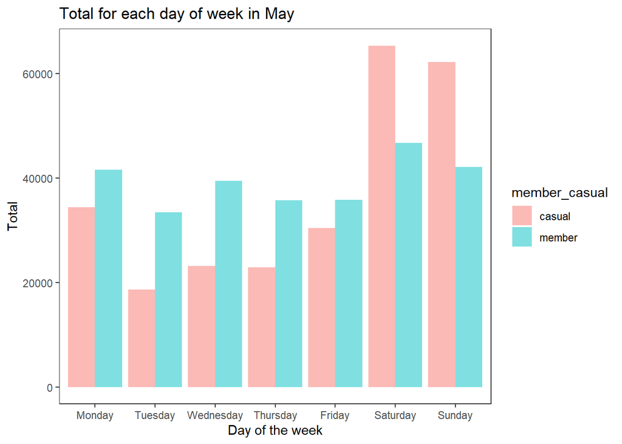

```r
may_df %>%
  ggplot(aes(x = day_of_week5, fill = member_casual)) +
  geom_bar(position = "dodge", alpha = 0.5) +
  theme_bw() +
  theme(panel.grid.major = element_blank(),
        panel.grid.minor = element_blank()) +
  labs(title = "Total for each day of week in May",
       x = "Day of the week", y = "Total")
```

Patronage rise generally showing close patronage figures with members surpassing Casuals on weekdays and Casuals surpassing Member users on the weekends

#### TOTAL BIKE TYPE USAGE FOR EACH DAY OF WEEK

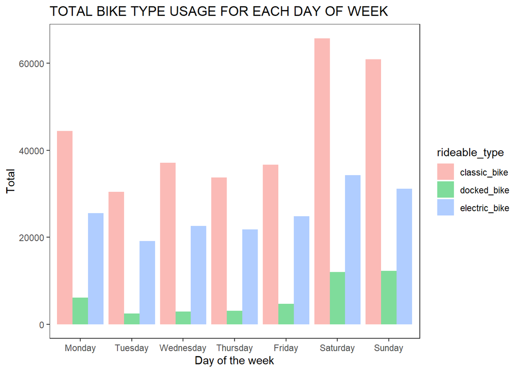

```r
may_df %>%
  ggplot(aes(x = day_of_week5, fill = rideable_type)) +
  geom_bar(position = "dodge", alpha = 0.5) +
  theme_bw() +
  theme(panel.grid.major = element_blank(),
        panel.grid.minor = element_blank()) +
  labs(title = "TOTAL BIKE TYPE USAGE FOR EACH DAY OF WEEK",
       x = "Day of the week", y = "Total")
```

#### TOTAL USAGE FOR EACH BIKE TYPE

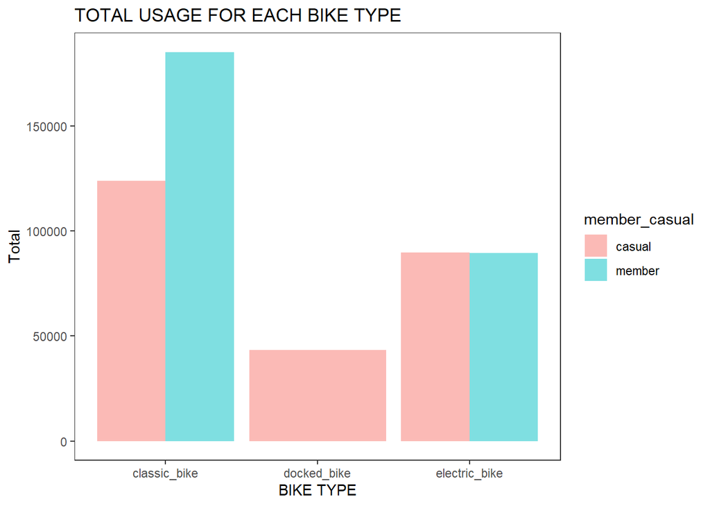

```r
may_df %>%
  ggplot(aes(x = rideable_type, fill = member_casual)) +
  geom_bar(position = "dodge", alpha = 0.5) +
  theme_bw() +
  theme(panel.grid.major = element_blank(),
        panel.grid.minor = element_blank()) +
  labs(title = "TOTAL USAGE FOR EACH BIKE TYPE",
       x = "BIKE TYPE", y = "Total")
```

High patronage for both Casual and Member users with Member Classic bike Users still surpassing Casual classic bike users but electric bike usage figures are similar

#### AVERAGE RIDE DURATION FOR CUSTOMER TYPES

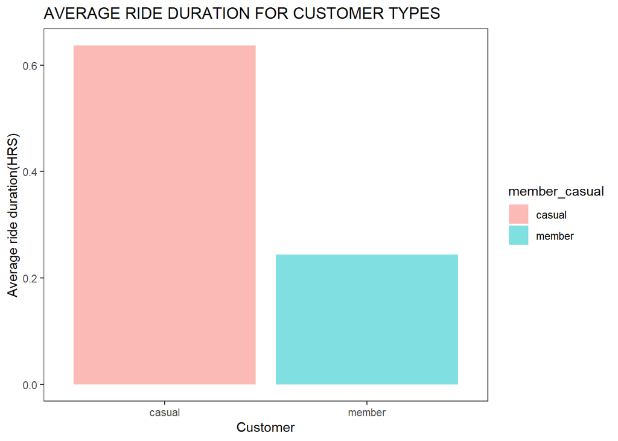

```r
ggplot(data = may_df, aes(x = member_casual, ride_duration_hrs, fill = member_casual)) +
  geom_bar(position = "dodge", stat = "summary",
           fun = "mean",alpha = 0.5) +
  theme_bw() +
  theme(panel.grid.major = element_blank(),
        panel.grid.minor = element_blank()) +
  labs(title = "AVERAGE RIDE DURATION FOR CUSTOMER TYPES",
       x = "Customer", y = "Average ride duration(HRS)")
```

High average ride duration for Casual Users

#### AVERAGE RIDE DURATION FOR DIFFERENT WEEKDAYS BASED ON CUSTOMER TYPES

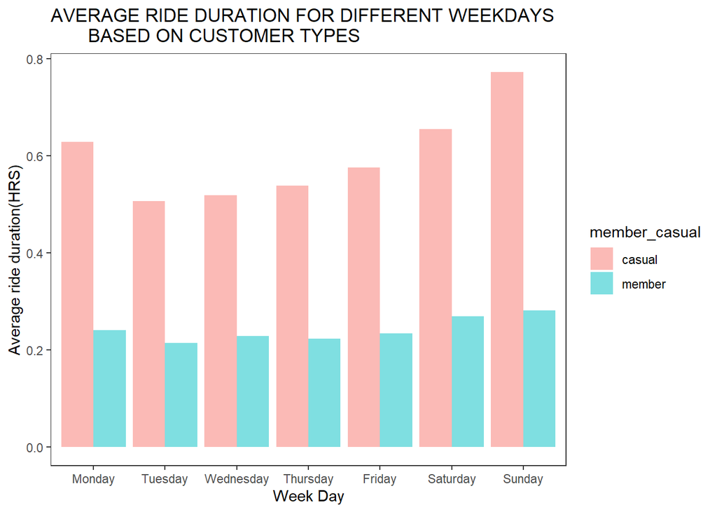

```r
ggplot(data = may_df, aes(x = day_of_week5, ride_duration_hrs, fill = member_casual)) +
  geom_bar(position = "dodge", stat = "summary", fun = "mean",alpha = 0.5) +
  theme_bw() +
  theme(panel.grid.major = element_blank(),
        panel.grid.minor = element_blank()) +
  labs(title = "AVERAGE RIDE DURATION FOR DIFFERENT WEEKDAYS
       BASED ON CUSTOMER TYPES",
       x = "Week Day", y = "Average ride duration(HRS)")
```

#### CUSTOMER AVERAGE RIDE DURATION FOR DIFFERENT BIKE TYPES

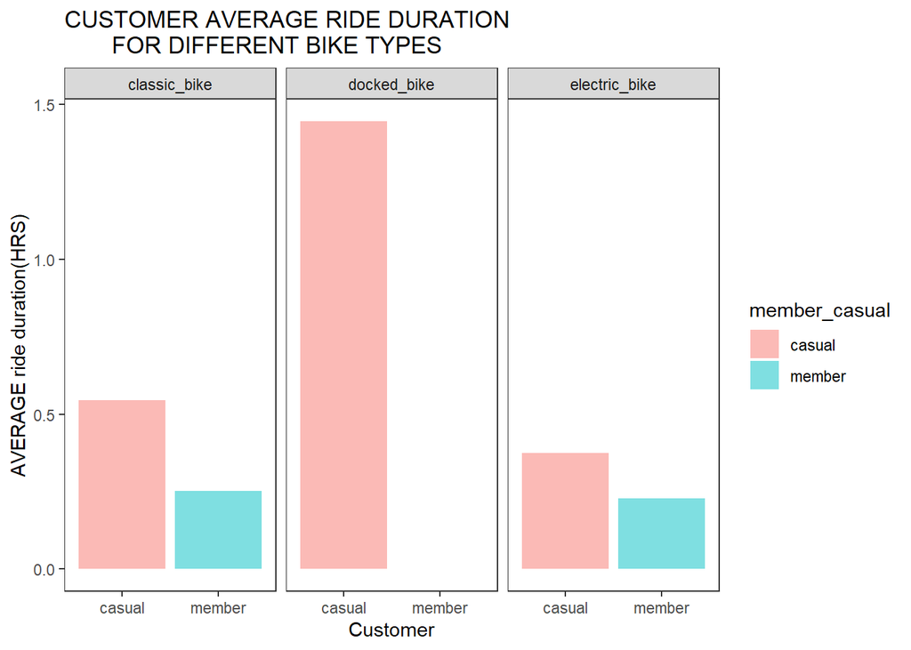

```r
ggplot(data = may_df, aes(x = member_casual, ride_duration_hrs, fill = member_casual)) +
  geom_bar(position = "dodge", stat = "summary",
           fun = "mean",alpha = 0.5) +
  facet_wrap(~rideable_type) +
  theme_bw() +
  theme(panel.grid.major = element_blank(),
        panel.grid.minor = element_blank()) +
  labs(title = "CUSTOMER AVERAGE RIDE DURATION
       FOR DIFFERENT BIKE TYPES",
       x = "Customer", y = "AVERAGE ride duration(HRS)")
```

Docked bikes had the highest averages

#### Max RIDE DURATION FOR CUSTOMER TYPES

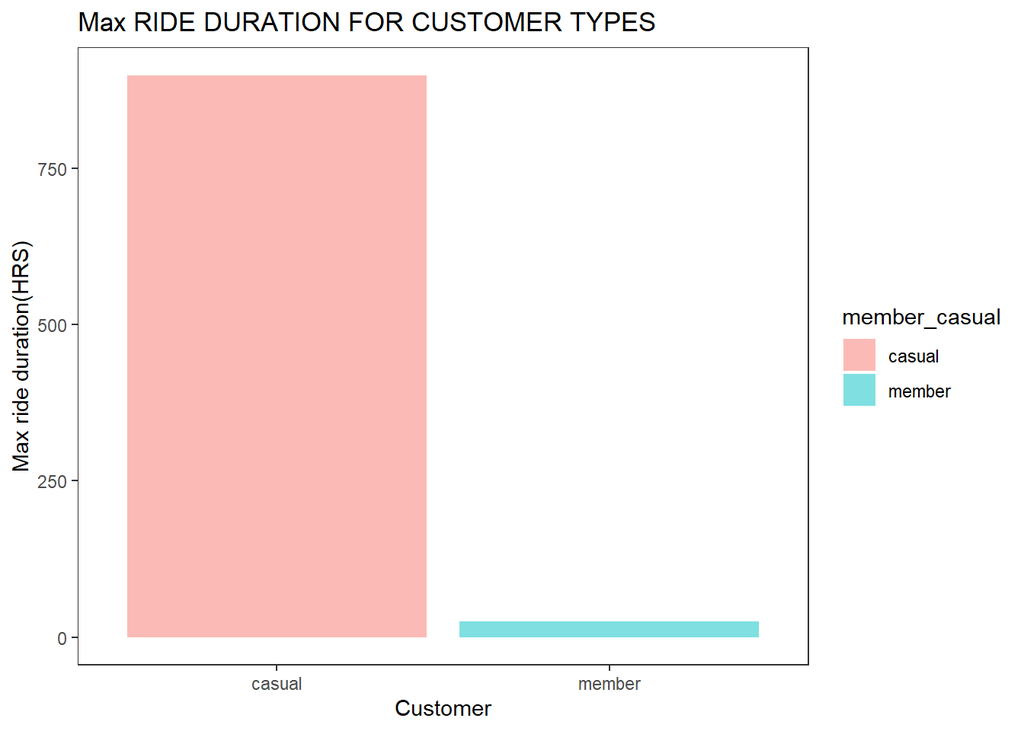

```r
ggplot(data = may_df, aes(x = member_casual, ride_duration_hrs, fill = member_casual)) +
  geom_bar(position = "dodge", stat = "summary",
           fun = "max",alpha = 0.5) +
  theme_bw() +
  theme(panel.grid.major = element_blank(),
        panel.grid.minor = element_blank()) +
  labs(title = "Max RIDE DURATION FOR CUSTOMER TYPES",
       x = "Customer", y = "Max ride duration(HRS)")
```

#### CUSTOMER Max RIDE DURATION FOR DIFFERENT BIKE TYPES

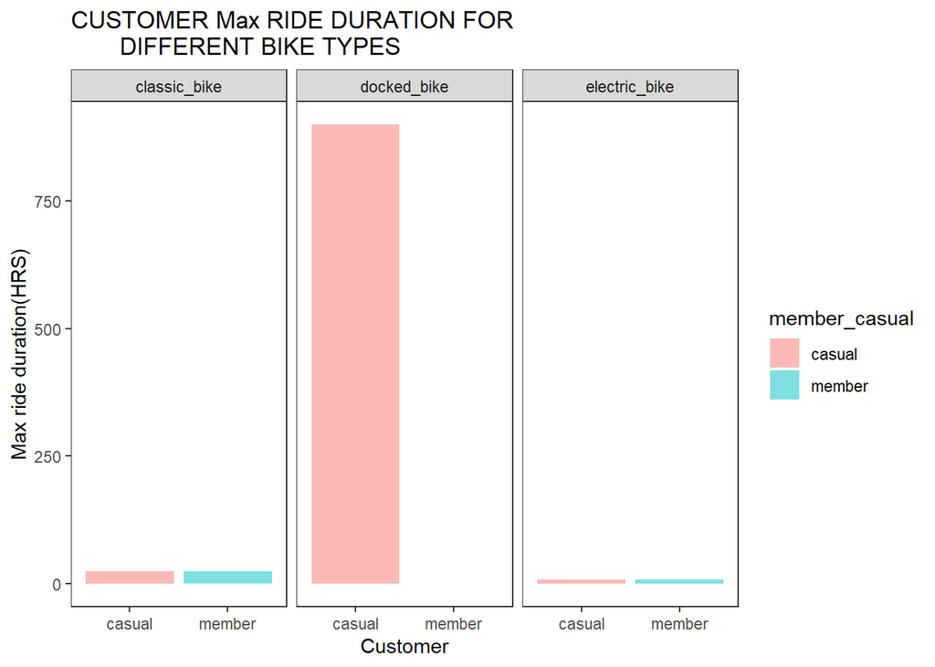

```r
ggplot(data = may_df, aes(x = member_casual, ride_duration_hrs, fill = member_casual)) +
  geom_bar(position = "dodge", stat = "summary",
           fun = "max",alpha = 0.5) +
  facet_wrap(~rideable_type) +
  theme_bw() +
  theme(panel.grid.major = element_blank(),
        panel.grid.minor = element_blank()) +
  labs(title = "CUSTOMER Max RIDE DURATION FOR
       DIFFERENT BIKE TYPES",
       x = "Customer", y = "Max ride duration(HRS)")
```

Docked bike type continue to maximum duration

### JUNE ANALYSIS

```r
jun_df <- read_csv("C:/Users/user/Desktop/Case Study/CASESTUDY CYCLING DATA/Cleaned Data/202106-divvy-tripdata_cleaned.csv")
head(jun_df)
```

```
## # A tibble: 6 x 18
##   ride_id        ridea~1 start~2 ended~3 ride_~4 ride_~5 day_o~6 start~7 start~8
##   <chr>          <chr>   <chr>   <chr>   <chr>   <time>  <chr>   <chr>   <chr>
## 1 99FEC93BA843F~ electr~ 6/13/2~ 6/13/2~ 6/13/2~ 02'43"  Sunday  <NA>    <NA>
## 2 06048DCFC8520~ electr~ 6/4/20~ 6/4/20~ 6/4/20~ 06'17"  Friday  <NA>    <NA>
## 3 9598066F68045~ electr~ 6/4/20~ 6/4/20~ 6/4/20~ 05'59"  Friday  <NA>    <NA>
## 4 B03C0FE48C412~ electr~ 6/3/20~ 6/3/20~ 6/3/20~ 25'50"  Thursd~ <NA>    <NA>
## 5 B9EEA89F8FEE7~ electr~ 6/4/20~ 6/4/20~ 6/4/20~ 04'08"  Friday  <NA>    <NA>
## 6 62B943CEAAA42~ electr~ 6/3/20~ 6/3/20~ 6/3/20~ 06'45"  Thursd~ <NA>    <NA>
## # ... with 9 more variables: end_station_name <chr>, end_station_id <chr>,
## #   start_lat <dbl>, start_lng <dbl>, end_lat <dbl>, end_lng <dbl>,
## #   member_casual <chr>, week_number <dbl>, ride_duration_hrs <dbl>, and
## #   abbreviated variable names 1: rideable_type, 2: started_at, 3: ended_at,
## #   4: ride_date, 5: ride_duration, 6: day_of_week, 7: start_station_name,
## #   8: start_station_id
## # i Use `colnames()` to see all variable names
```

#### Ordering the days of the week

```r
jun_df$day_of_week6 <- factor(jun_df$day_of_week, levels = c("Monday", "Tuesday", "Wednesday", "Thursday", "Friday", "Saturday", "Sunday"))
```

#### Total for each day of week

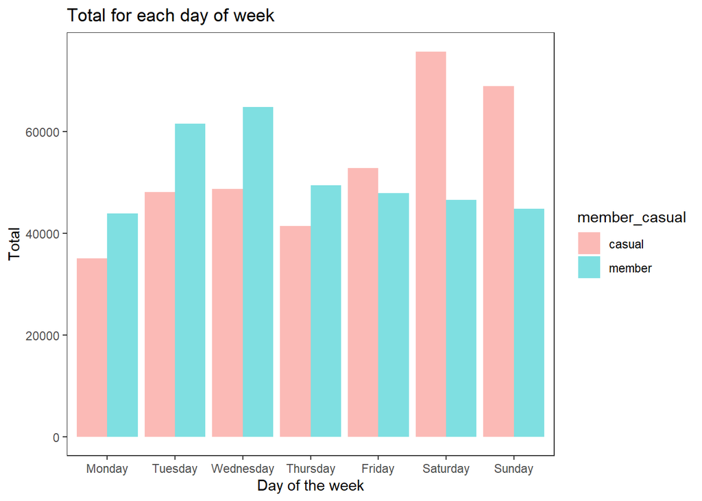

```r
jun_df %>%
  ggplot(aes(x = day_of_week6, fill = member_casual)) +
  geom_bar(position = "dodge", alpha = 0.5) +
  theme_bw() +
  theme(panel.grid.major = element_blank(),
        panel.grid.minor = element_blank()) +
  labs(title = "Total for each day of week",
       x = "Day of the week", y = "Total")
```

Close total patronage for different customer types with higher numbers for casual users on weekends

#### TOTAL BIKE TYPE USAGE FOR EACH DAY OF WEEK

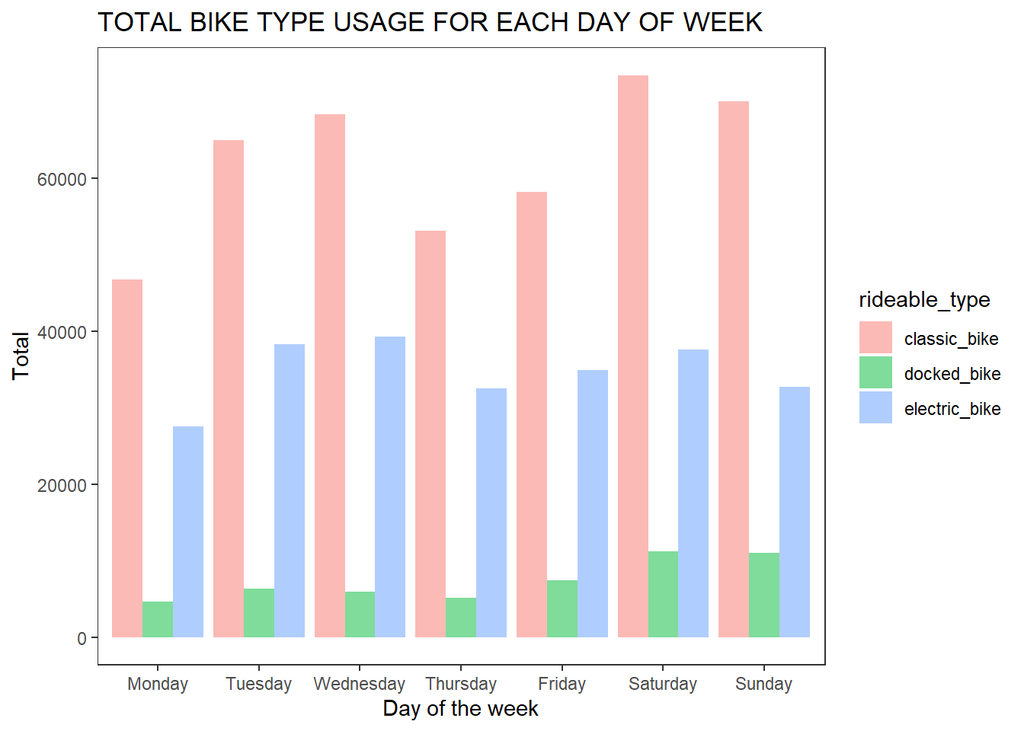

```r
jun_df %>%
  ggplot(aes(x = day_of_week6, fill = rideable_type)) +
  geom_bar(position = "dodge", alpha = 0.5) +
  theme_bw() +
  theme(panel.grid.major = element_blank(),
        panel.grid.minor = element_blank()) +
  labs(title = "TOTAL BIKE TYPE USAGE FOR EACH DAY OF WEEK",
       x = "Day of the week", y = "Total")
```

Higher patronage for classic bikes and then electric bikes

#### TOTAL USAGE FOR EACH BIKE TYPE

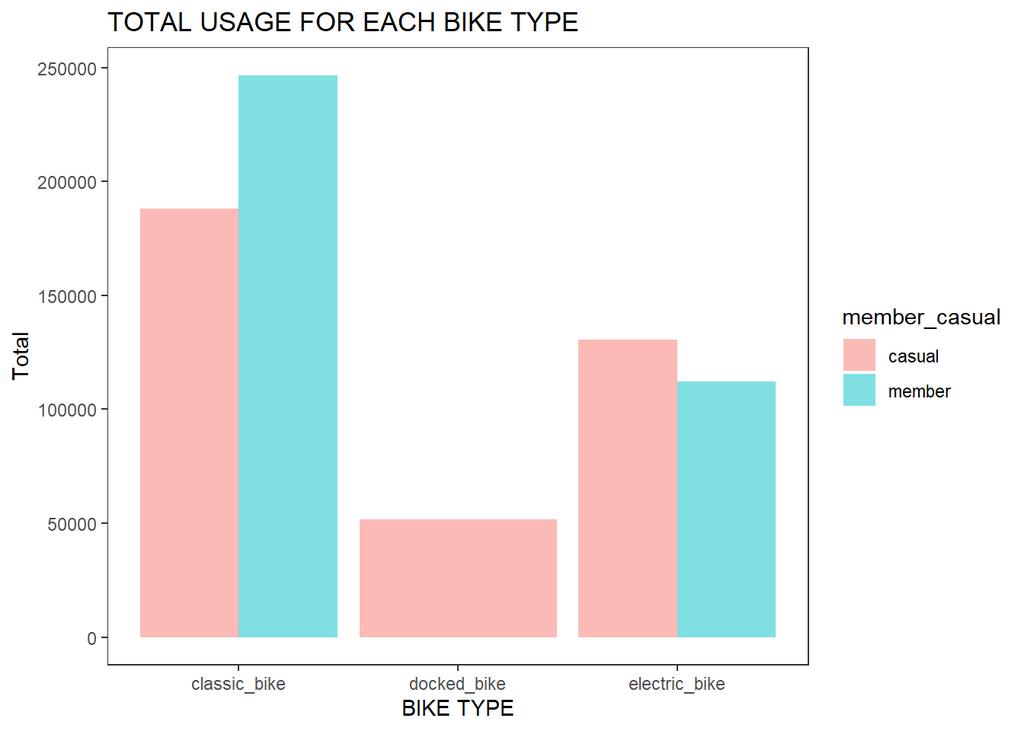

```r
jun_df %>%
  ggplot(aes(x = rideable_type, fill = member_casual)) +
  geom_bar(position = "dodge", alpha = 0.5) +
  theme_bw() +
  theme(panel.grid.major = element_blank(),
        panel.grid.minor = element_blank()) +
  labs(title = "TOTAL USAGE FOR EACH BIKE TYPE",
       x = "BIKE TYPE", y = "Total")
```

Close Patronage figures both Casual and Member Users for different bike types

#### AVERAGE RIDE DURATION FOR CUSTOMER TYPES

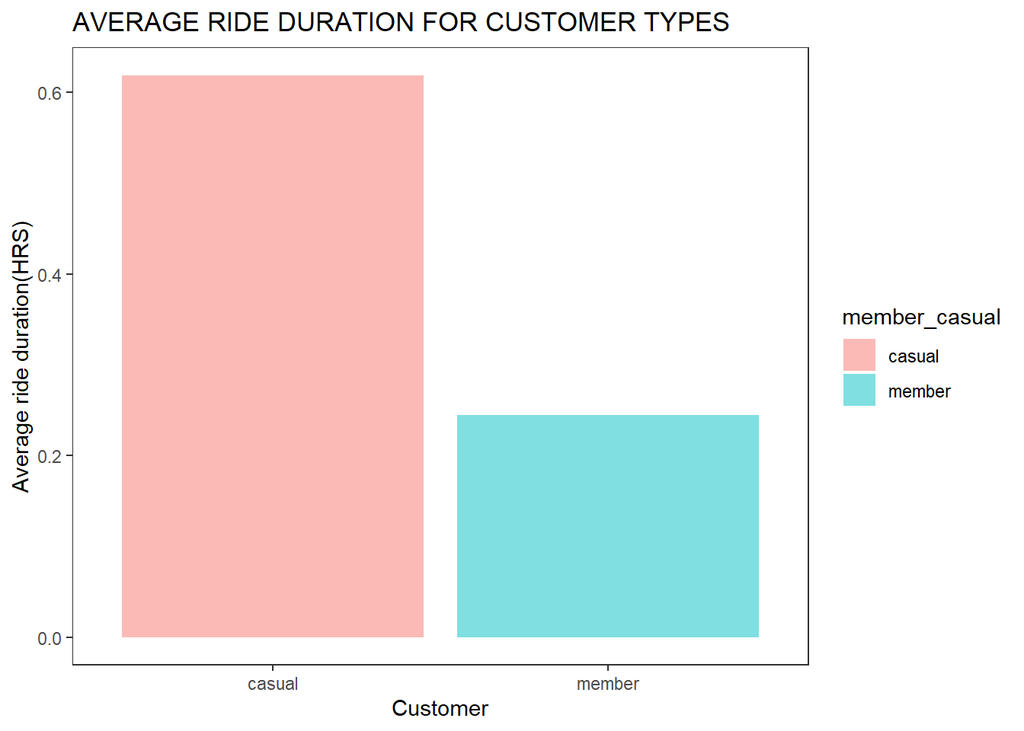

```r
ggplot(data = jun_df, aes(x = member_casual, ride_duration_hrs, fill = member_casual)) +
  geom_bar(position = "dodge", stat = "summary",
           fun = "mean",alpha = 0.5) +
  theme_bw() +
  theme(panel.grid.major = element_blank(),
        panel.grid.minor = element_blank()) +
  labs(title = "AVERAGE RIDE DURATION FOR CUSTOMER TYPES",
       x = "Customer", y = "Average ride duration(HRS)")
```

Casual Users average ride duration are higher compared to Member users

#### AVERAGE RIDE DURATION FOR DIFFERENT WEEKDAYS BASED ON CUSTOMER TYPES

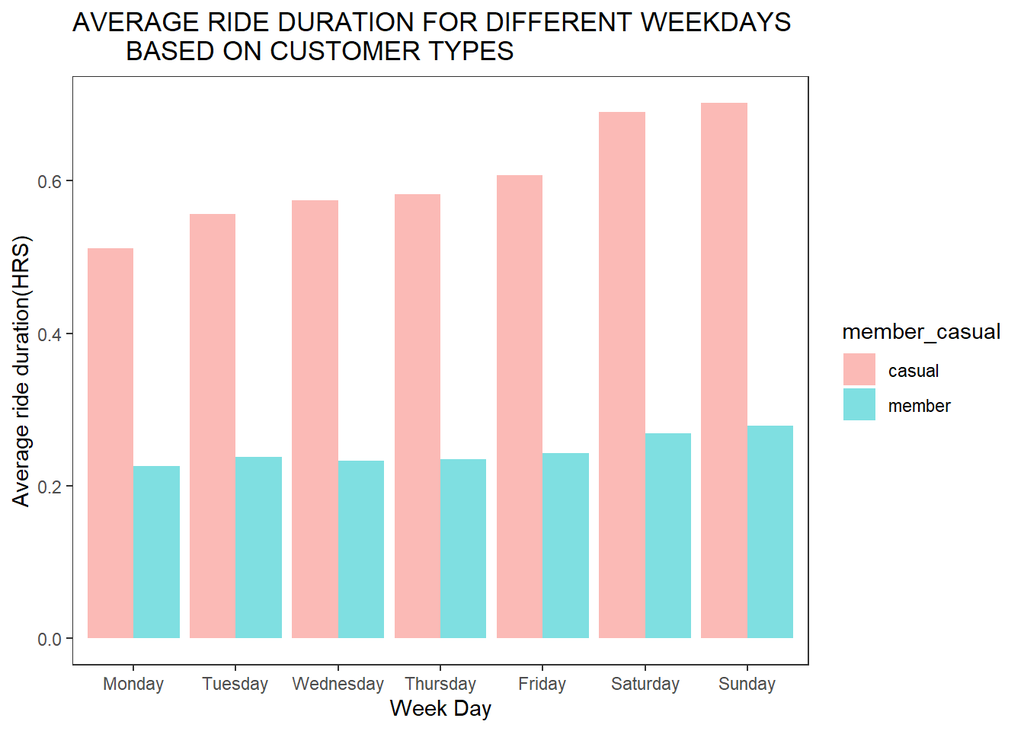

```r
ggplot(data = jun_df, aes(x = day_of_week6, ride_duration_hrs, fill = member_casual)) +
  geom_bar(position = "dodge", stat = "summary", fun = "mean",alpha = 0.5) +
  theme_bw() +
  theme(panel.grid.major = element_blank(),
        panel.grid.minor = element_blank()) +
  labs(title = "AVERAGE RIDE DURATION FOR DIFFERENT WEEKDAYS
       BASED ON CUSTOMER TYPES",
       x = "Week Day", y = "Average ride duration(HRS)")
```

#### CUSTOMER AVERAGE RIDE DURATION FOR DIFFERENT BIKE TYPES

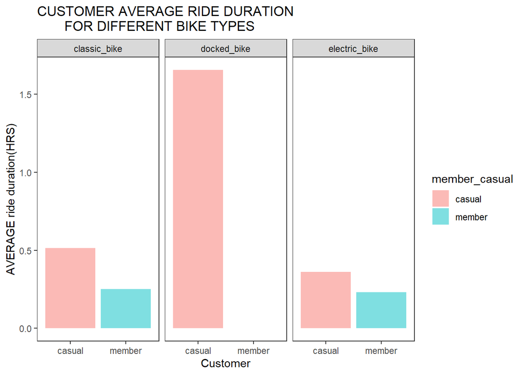

```r
ggplot(data = jun_df, aes(x = member_casual, ride_duration_hrs, fill = member_casual)) +
  geom_bar(position = "dodge", stat = "summary", fun = "mean",alpha = 0.5) +
  facet_wrap(~rideable_type) +
  theme_bw() +
  theme(panel.grid.major = element_blank(),
        panel.grid.minor = element_blank()) +
  labs(title = "CUSTOMER AVERAGE RIDE DURATION
       FOR DIFFERENT BIKE TYPES",
       x = "Customer", y = "AVERAGE ride duration(HRS)")
```

Docked bike types continue to be the longest driven bike types

#### Max RIDE DURATION FOR CUSTOMER TYPES

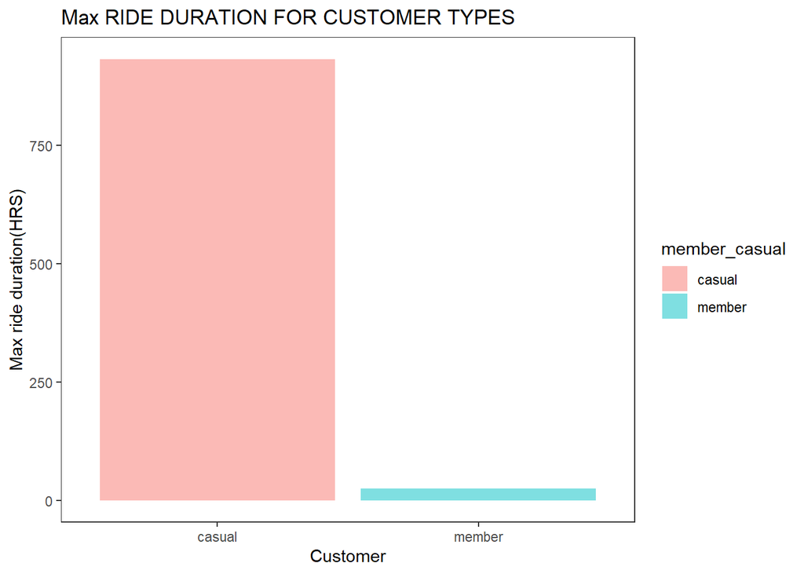

```r
ggplot(data = jun_df, aes(x = member_casual, ride_duration_hrs, fill = member_casual)) +
  geom_bar(position = "dodge", stat = "summary",
           fun = "max",alpha = 0.5) +
  theme_bw() +
  theme(panel.grid.major = element_blank(),
        panel.grid.minor = element_blank()) +
  labs(title = "Max RIDE DURATION FOR CUSTOMER TYPES",
       x = "Customer", y = "Max ride duration(HRS)")
```

Casual bike users recorded maximum duration

#### CUSTOMER Max RIDE DURATION FOR DIFFERENT BIKE TYPES

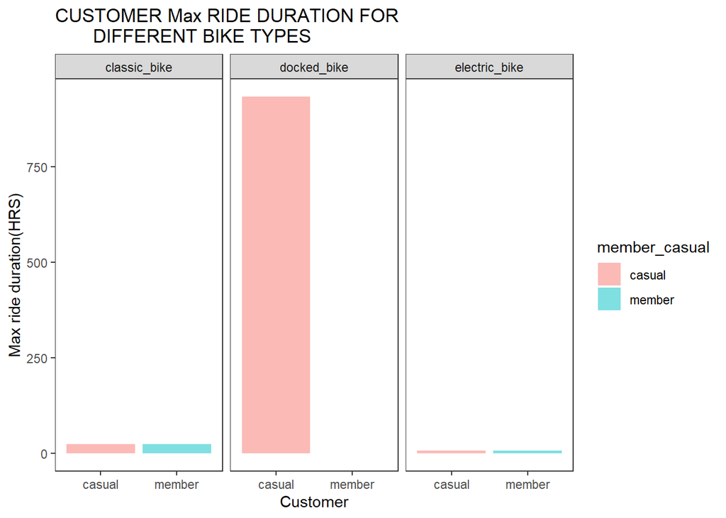

```r
ggplot(data = jun_df, aes(x = member_casual, ride_duration_hrs, fill = member_casual)) +
  geom_bar(position = "dodge", stat = "summary",
           fun = "max",alpha = 0.5) +
  facet_wrap(~rideable_type) +
  theme_bw() +
  theme(panel.grid.major = element_blank(),
        panel.grid.minor = element_blank()) +
  labs(title = "CUSTOMER Max RIDE DURATION FOR
       DIFFERENT BIKE TYPES",
       x = "Customer", y = "Max ride duration(HRS)")
```

### JULY ANALYSIS

```r
jul_df <- read_csv("C:/Users/user/Desktop/Case Study/CASESTUDY CYCLING DATA/Cleaned Data/202107-divvy-tripdata_cleaned.csv")
head(jul_df)
```

```
## # A tibble: 6 x 18
##   ride_id        ridea~1 start~2 ended~3 ride_~4 ride_~5 day_o~6 start~7 start~8
##   <chr>          <chr>   <chr>   <chr>   <chr>   <time>  <chr>   <chr>   <chr>
## 1 0A1B623926EF4~ docked~ 7/2/20~ 7/2/20~ 7/2/20~ 35'22"  Friday  Michig~ 13001
## 2 B2D5583A5A5E7~ classi~ 7/7/20~ 7/7/20~ 7/7/20~ 18'27"  Wednes~ Califo~ 17660
## 3 6F264597DDBF4~ classi~ 7/25/2~ 7/25/2~ 7/25/2~ 17'50"  Sunday  Wabash~ SL-012
## 4 379B58EAB20E8~ classi~ 7/8/20~ 7/8/20~ 7/8/20~ 15'02"  Thursd~ Califo~ 17660
## 5 6615C1E4EB08E~ electr~ 7/28/2~ 7/28/2~ 7/28/2~ 19'03"  Wednes~ Califo~ 17660
## 6 62DC2B32872F9~ electr~ 7/29/2~ 7/29/2~ 7/29/2~ 05'52"  Thursd~ Califo~ 17660
## # ... with 9 more variables: end_station_name <chr>, end_station_id <chr>,
## #   start_lat <dbl>, start_lng <dbl>, end_lat <dbl>, end_lng <dbl>,
## #   member_casual <chr>, week_number <dbl>, ride_duration_hrs <dbl>, and
## #   abbreviated variable names 1: rideable_type, 2: started_at, 3: ended_at,
## #   4: ride_date, 5: ride_duration, 6: day_of_week, 7: start_station_name,
## #   8: start_station_id
## # i Use `colnames()` to see all variable names
```

#### Ordering the days of the week

```r
jul_df$day_of_week7 <- factor(jul_df$day_of_week, levels = c("Monday", "Tuesday", "Wednesday", "Thursday", "Friday", "Saturday", "Sunday"))
```

#### Total number of users for each week

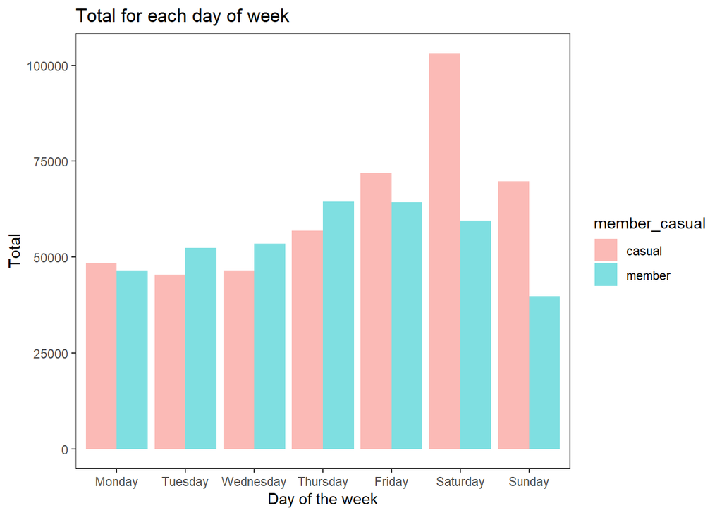

```r
jul_df %>%
  ggplot(aes(x = day_of_week7, fill = member_casual)) +
  geom_bar(position = "dodge", alpha = 0.5) +
  theme_bw() +
  theme(panel.grid.major = element_blank(),
        panel.grid.minor = element_blank()) +
  labs(title = "Total for each day of week",
       x = "Day of the week", y = "Total")
```

Close total patronage for different Users with increased numbers on the Weekend for Casual users

#### TOTAL BIKE TYPE USAGE FOR EACH DAY OF WEEK

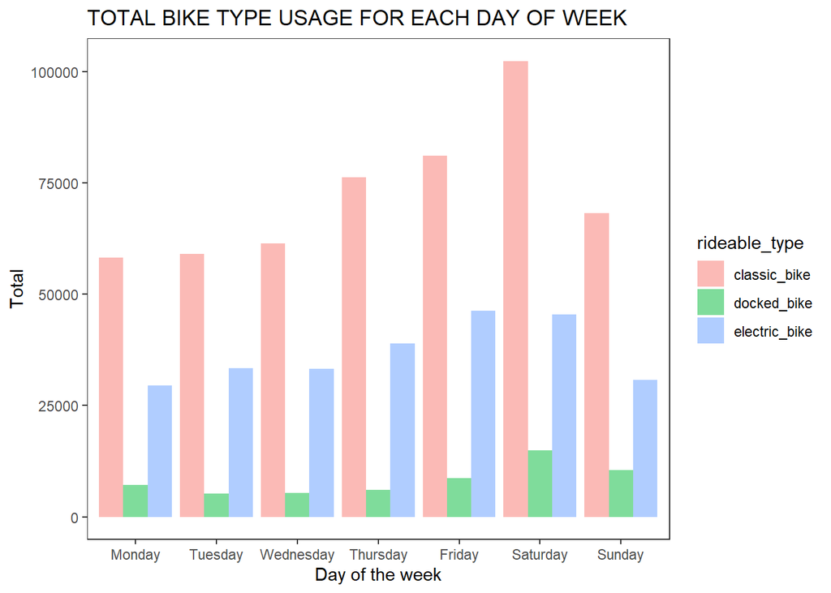

```r
jul_df %>%
  ggplot(aes(x = day_of_week7, fill = rideable_type)) +
  geom_bar(position = "dodge", alpha = 0.5) +
  theme_bw() +
  theme(panel.grid.major = element_blank(),
        panel.grid.minor = element_blank()) +
  labs(title = "TOTAL BIKE TYPE USAGE FOR EACH DAY OF WEEK",
       x = "Day of the week", y = "Total")
```

Classic bike types remain the most preferred bike

#### TOTAL USAGE FOR EACH BIKE TYPE

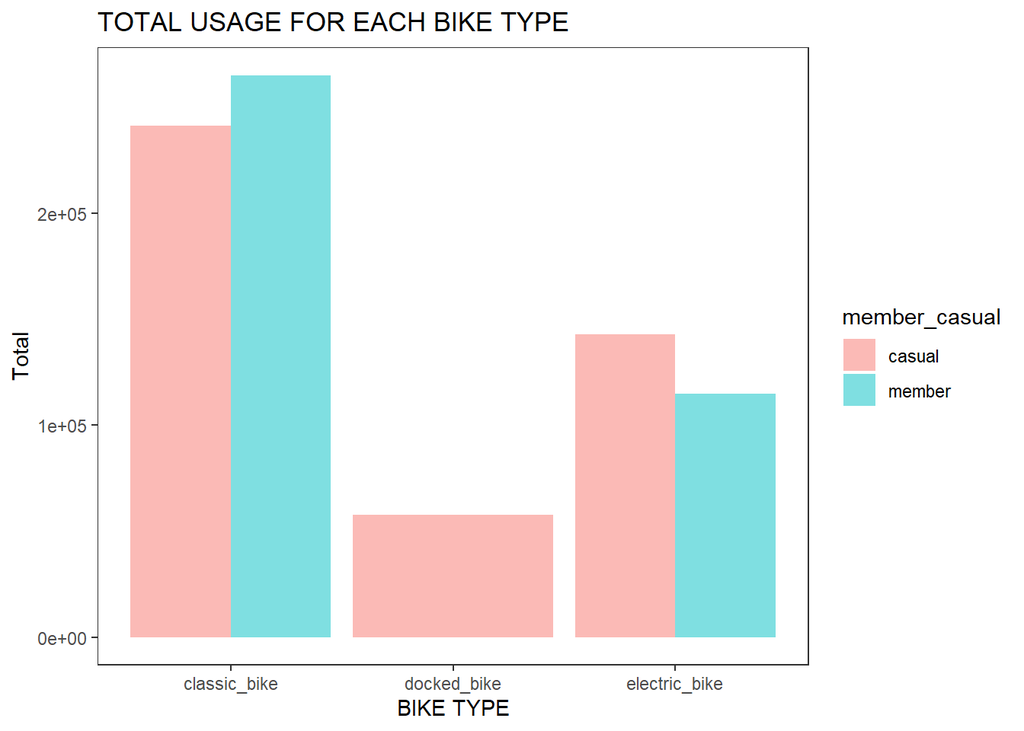

```r
jul_df %>%
  ggplot(aes(x = rideable_type, fill = member_casual)) +
  geom_bar(position = "dodge", alpha = 0.5) +
  theme_bw() +
  theme(panel.grid.major = element_blank(),
        panel.grid.minor = element_blank()) +
  labs(title = "TOTAL USAGE FOR EACH BIKE TYPE",
       x = "BIKE TYPE", y = "Total")
```

Close patronage for different bike types with casual user having higher numbers than member users for electric bike types

#### AVERAGE RIDE DURATION FOR CUSTOMER TYPES

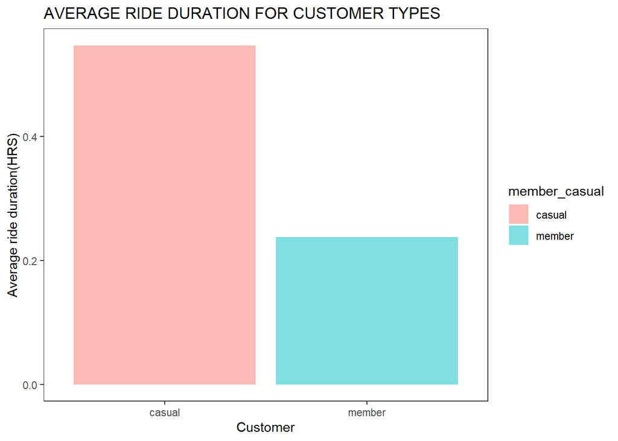

```r
ggplot(data = jul_df, aes(x = member_casual, ride_duration_hrs, fill = member_casual)) +
  geom_bar(position = "dodge", stat = "summary",
           fun = "mean",alpha = 0.5) +
  theme_bw() +
  theme(panel.grid.major = element_blank(),
        panel.grid.minor = element_blank()) +
  labs(title = "AVERAGE RIDE DURATION FOR CUSTOMER TYPES",
       x = "Customer", y = "Average ride duration(HRS)")
```

Casual members continue to have high averages

#### AVERAGE RIDE DURATION FOR DIFFERENT WEEKDAYS BASED ON CUSTOMER TYPES

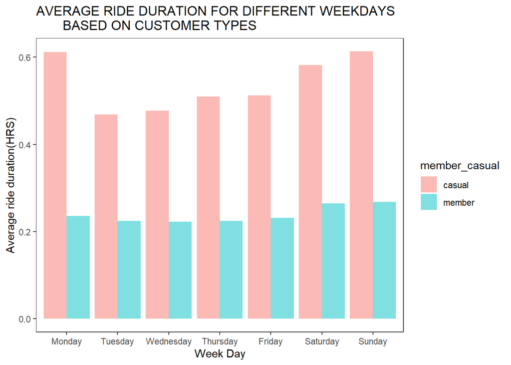

```r
ggplot(data = jul_df, aes(x = day_of_week7, ride_duration_hrs, fill = member_casual)) +
  geom_bar(position = "dodge", stat = "summary",
           fun = "mean",alpha = 0.5) +
  theme_bw() +
  theme(panel.grid.major = element_blank(),
        panel.grid.minor = element_blank()) +
  labs(title = "AVERAGE RIDE DURATION FOR DIFFERENT WEEKDAYS
       BASED ON CUSTOMER TYPES",
       x = "Week Day", y = "Average ride duration(HRS)")
```

#### CUSTOMER AVERAGE RIDE DURATION FOR DIFFERENT BIKE TYPES

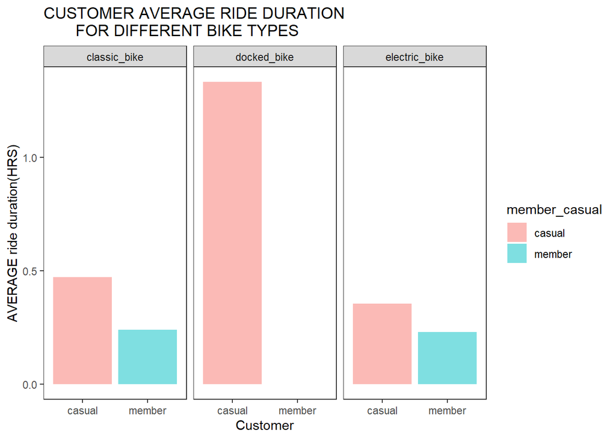

```r
ggplot(data = jul_df, aes(x = member_casual, ride_duration_hrs, fill = member_casual)) +
  geom_bar(position = "dodge", stat = "summary",
           fun = "mean",alpha = 0.5) +
  facet_wrap(~rideable_type) +
  theme_bw() +
  theme(panel.grid.major = element_blank(),
        panel.grid.minor = element_blank()) +
  labs(title = "CUSTOMER AVERAGE RIDE DURATION
       FOR DIFFERENT BIKE TYPES",
       x = "Customer", y = "AVERAGE ride duration(HRS)")
```

Docked bike types remain the longest ridden bike

#### Max RIDE DURATION FOR CUSTOMER TYPES

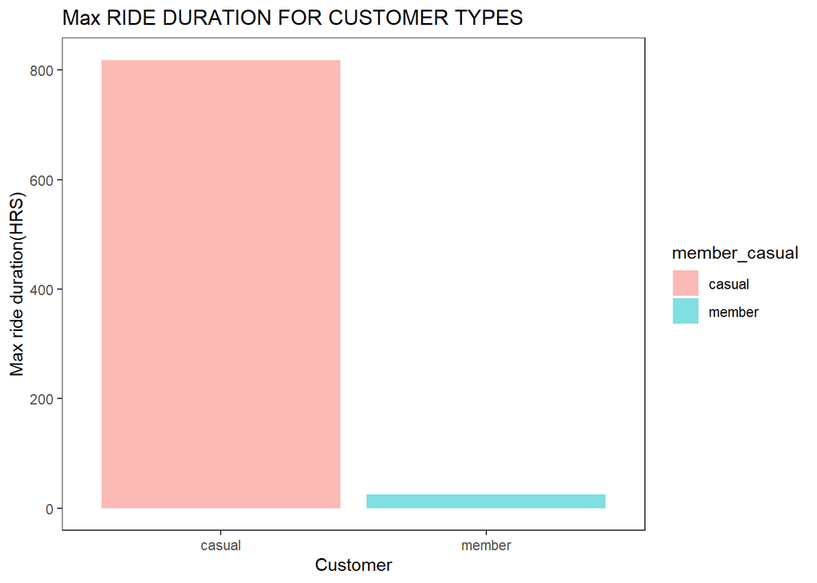

```r
ggplot(data = jul_df, aes(x = member_casual, ride_duration_hrs, fill = member_casual)) +
  geom_bar(position = "dodge", stat = "summary",
           fun = "max",alpha = 0.5) +
  theme_bw() +
  theme(panel.grid.major = element_blank(),
        panel.grid.minor = element_blank()) +
  labs(title = "Max RIDE DURATION FOR CUSTOMER TYPES",
       x = "Customer", y = "Max ride duration(HRS)")
```

#### CUSTOMER Max RIDE DURATION FOR DIFFERENT BIKE TYPES

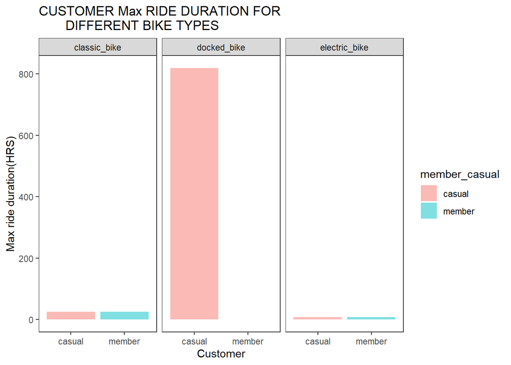

```r
ggplot(data = jul_df, aes(x = member_casual, ride_duration_hrs, fill = member_casual)) +
  geom_bar(position = "dodge", stat = "summary", fun = "max",alpha = 0.5) +
  facet_wrap(~rideable_type) +
  theme_bw() +
  theme(panel.grid.major = element_blank(),
        panel.grid.minor = element_blank()) +
  labs(title = "CUSTOMER Max RIDE DURATION FOR
       DIFFERENT BIKE TYPES",
       x = "Customer", y = "Max ride duration(HRS)")
```

Docked bike types by casual users recorded the max ride duration

### AUGUST ANALYSIS

```r
aug_df <- read_csv("C:/Users/user/Desktop/Case Study/CASESTUDY CYCLING DATA/Cleaned Data/202108-divvy-tripdata_cleaned.csv")
head(aug_df)
```

```
## # A tibble: 6 x 18
##   ride_id        ridea~1 start~2 ended~3 ride_~4 ride_~5 day_o~6 start~7 start~8
##   <chr>          <chr>   <chr>   <chr>   <chr>   <time>  <chr>   <chr>   <chr>
## 1 99103BB87CC6C~ electr~ 8/10/2~ 8/10/2~ 8/10/2~ 06'55"  Tuesday <NA>    <NA>
## 2 EAFCCCFB0A3FC~ electr~ 8/10/2~ 8/10/2~ 8/10/2~ 16'10"  Tuesday <NA>    <NA>
## 3 9EF4F46C57AD2~ electr~ 8/21/2~ 8/21/2~ 8/21/2~ 16'13"  Saturd~ <NA>    <NA>
## 4 5834D3208BFAF~ electr~ 8/21/2~ 8/21/2~ 8/21/2~ 15'18"  Saturd~ <NA>    <NA>
## 5 CD825CB87ED1D~ electr~ 8/19/2~ 8/19/2~ 8/19/2~ 08'42"  Thursd~ <NA>    <NA>
## 6 612F12C94A964~ electr~ 8/19/2~ 8/19/2~ 8/19/2~ 06'35"  Thursd~ <NA>    <NA>
## # ... with 9 more variables: end_station_name <chr>, end_station_id <chr>,
## #   start_lat <dbl>, start_lng <dbl>, end_lat <dbl>, end_lng <dbl>,
## #   member_casual <chr>, week_number <dbl>, ride_duration_hrs <dbl>, and
## #   abbreviated variable names 1: rideable_type, 2: started_at, 3: ended_at,
## #   4: ride_date, 5: ride_duration, 6: day_of_week, 7: start_station_name,
## #   8: start_station_id
## # i Use `colnames()` to see all variable names
```

#### Ordering the days of the week

```r
aug_df$day_of_week8 <- factor(aug_df$day_of_week, levels = c("Monday", "Tuesday", "Wednesday", "Thursday", "Friday", "Saturday", "Sunday"))
```

#### Total for each day of week

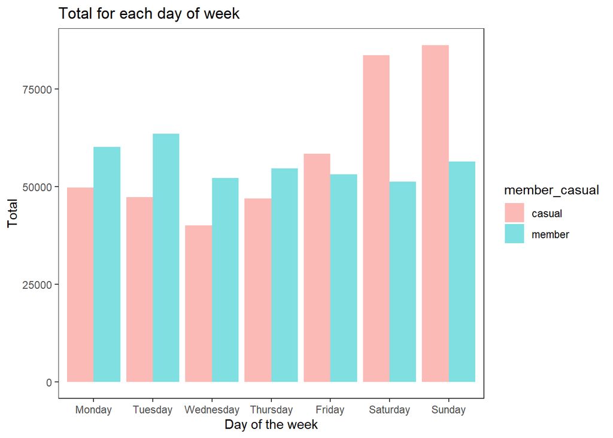

```r
aug_df %>%
  ggplot(aes(x = day_of_week8, fill = member_casual)) +
  geom_bar(position = "dodge", alpha = 0.5) +
  theme_bw() +
  theme(panel.grid.major = element_blank(),
        panel.grid.minor = element_blank()) +
  labs(title = "Total for each day of week",
       x = "Day of the week", y = "Total")
```

Close figures on weekdays for different user types and higher figures on the weekend for Casual Users

#### TOTAL BIKE TYPE USAGE FOR EACH DAY OF WEEK

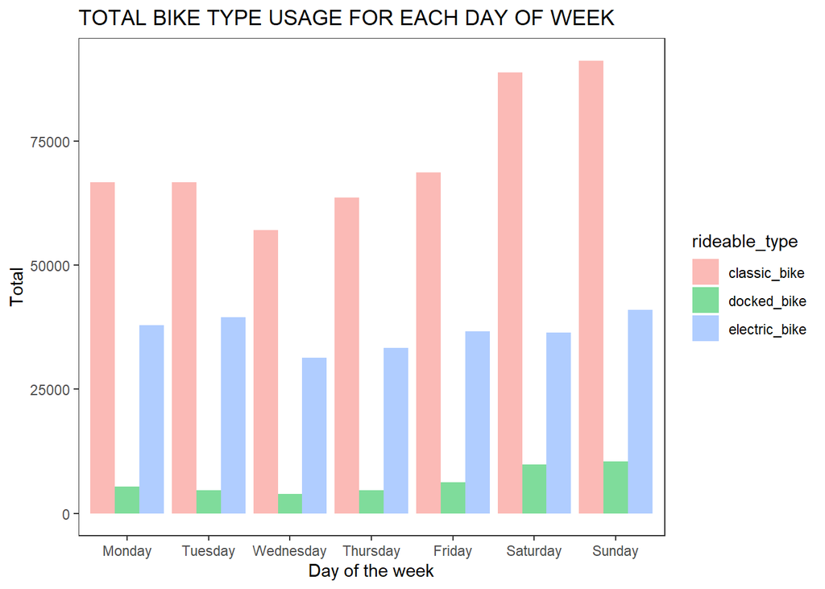

```r
aug_df %>%
  ggplot(aes(x = day_of_week8, fill = rideable_type)) +
  geom_bar(position = "dodge", alpha = 0.5) +
  theme_bw() +
  theme(panel.grid.major = element_blank(),
        panel.grid.minor = element_blank()) +
  labs(title = "TOTAL BIKE TYPE USAGE FOR EACH DAY OF WEEK",
       x = "Day of the week", y = "Total")
```

#### TOTAL USAGE FOR EACH BIKE TYPE

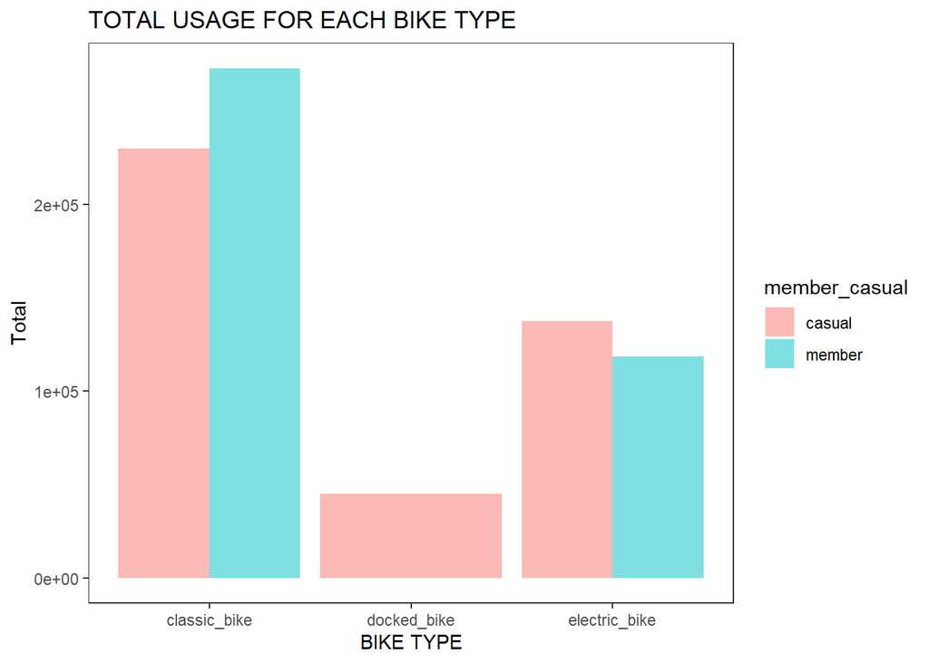

```r
aug_df %>%
  ggplot(aes(x = rideable_type, fill = member_casual)) +
  geom_bar(position = "dodge", alpha = 0.5) +
  theme_bw() +
  theme(panel.grid.major = element_blank(),
        panel.grid.minor = element_blank()) +
  labs(title = "TOTAL USAGE FOR EACH BIKE TYPE",
       x = "BIKE TYPE", y = "Total")
```

Close figures for both electric bikes and classic bike tpes

#### AVERAGE RIDE DURATION FOR CUSTOMER TYPES

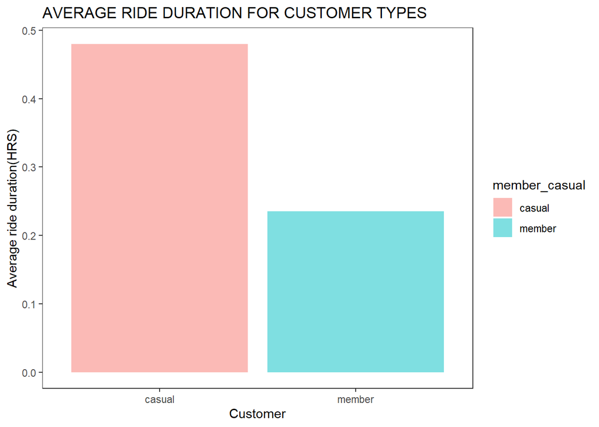

```r
ggplot(data = aug_df, aes(x = member_casual, ride_duration_hrs, fill = member_casual)) +
  geom_bar(position = "dodge", stat = "summary", fun = "mean",alpha = 0.5) +
  theme_bw() +
  theme(panel.grid.major = element_blank(),
        panel.grid.minor = element_blank()) +
  labs(title = "AVERAGE RIDE DURATION FOR CUSTOMER TYPES",
       x = "Customer", y = "Average ride duration(HRS)")
```

Casual user types continue to have higher averages

#### AVERAGE RIDE DURATION FOR DIFFERENT WEEKDAYS BASED ON CUSTOMER TYPES

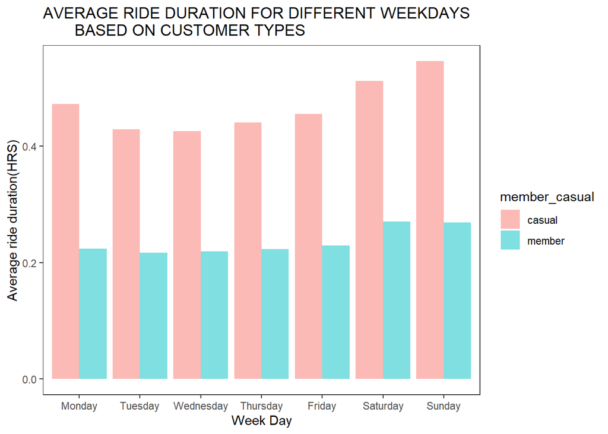

```r
ggplot(data = aug_df, aes(x = day_of_week8, ride_duration_hrs, fill = member_casual)) +
  geom_bar(position = "dodge", stat = "summary", fun = "mean",alpha = 0.5) +
  theme_bw() +
  theme(panel.grid.major = element_blank(),
        panel.grid.minor = element_blank()) +
  labs(title = "AVERAGE RIDE DURATION FOR DIFFERENT WEEKDAYS
       BASED ON CUSTOMER TYPES",
       x = "Week Day", y = "Average ride duration(HRS)")
```

#### CUSTOMER AVERAGE RIDE DURATION FOR DIFFERENT BIKE TYPES

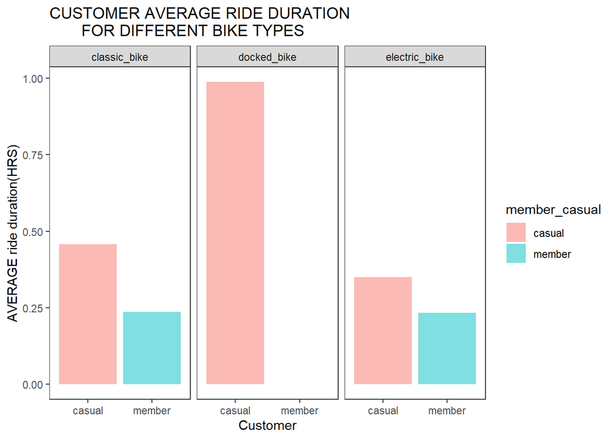

```r
ggplot(data = aug_df, aes(x = member_casual, ride_duration_hrs, fill = member_casual)) +
  geom_bar(position = "dodge", stat = "summary",
           fun = "mean",alpha = 0.5) +
  facet_wrap(~rideable_type) +
  theme_bw() +
  theme(panel.grid.major = element_blank(),
        panel.grid.minor = element_blank()) +
  labs(title = "CUSTOMER AVERAGE RIDE DURATION
       FOR DIFFERENT BIKE TYPES",
       x = "Customer", y = "AVERAGE ride duration(HRS)")
```

Casual Users continue to show higher averages for different bike types

#### Max RIDE DURATION FOR CUSTOMER TYPES

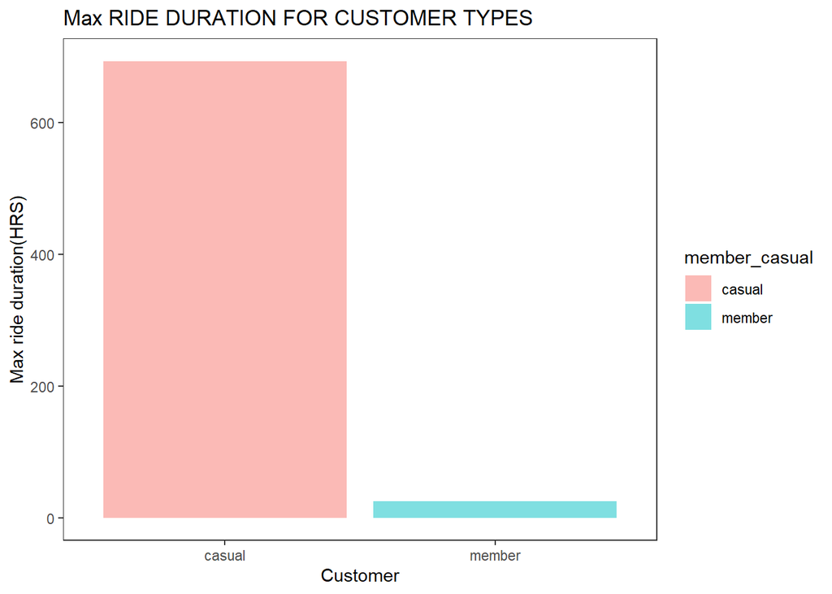

```r
ggplot(data = aug_df, aes(x = member_casual, ride_duration_hrs, fill = member_casual)) +
  geom_bar(position = "dodge", stat = "summary",
           fun = "max",alpha = 0.5) +
  theme_bw() +
  theme(panel.grid.major = element_blank(),
        panel.grid.minor = element_blank()) +
  labs(title = "Max RIDE DURATION FOR CUSTOMER TYPES",
       x = "Customer", y = "Max ride duration(HRS)")
```

#### CUSTOMER Max RIDE DURATION FOR DIFFERENT BIKE TYPES

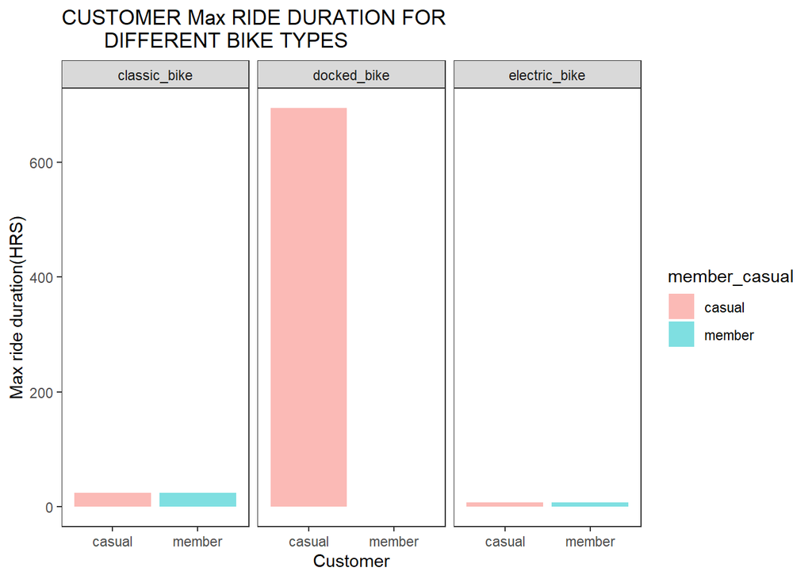

```r
ggplot(data = aug_df, aes(x = member_casual, ride_duration_hrs, fill = member_casual)) +
  geom_bar(position = "dodge", stat = "summary",
           fun = "max",alpha = 0.5) +
  facet_wrap(~rideable_type) +
  theme_bw() +
  theme(panel.grid.major = element_blank(),
        panel.grid.minor = element_blank()) +
  labs(title = "CUSTOMER Max RIDE DURATION FOR
       DIFFERENT BIKE TYPES",
       x = "Customer", y = "Max ride duration(HRS)")
```